# Process visualization Statistical models

## Model 0: comparing logistic with linear for task 3-6

Model 0 compares a multilevel logistic regression (a) for tasks 3-6 (that have a binary outcome) against a linear model. The two models are compared side by side and we see similar significant effects in both models for the same factors. An estimated means plot is provided for both models. As the models are comparable we are able to run one (linear model across all 6 tasks in the next section.

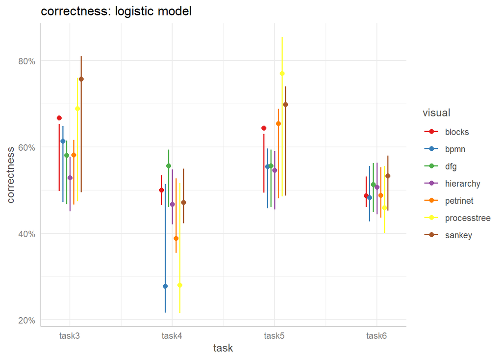

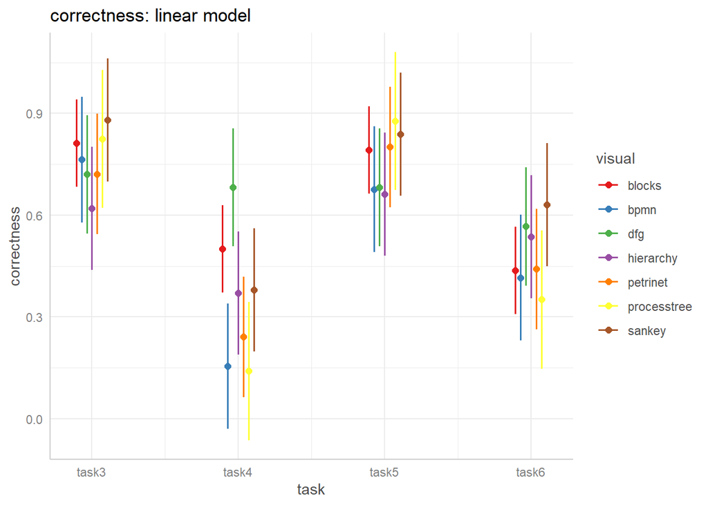

|  | logistic regression on correctness tasks 3-6 |  |  | linear regression on correctness task 3-6 |  |  |
| --- | --- | --- | --- | --- | --- | --- |
| Predictors | Odds Ratios | std. Error | p | Estimates | std. Error | p |
| (Intercept) | 4.63 | 1.77 | **<0.001** | 0.81 | 0.07 | **<0.001** |
| task [task4] | 0.22 | 0.10 | **0.001** | -0.31 | 0.09 | **0.001** |
| task [task5] | 0.87 | 0.45 | 0.794 | -0.02 | 0.09 | 0.819 |
| task [task6] | 0.17 | 0.08 | **<0.001** | -0.37 | 0.09 | **<0.001** |
| visual [bpmn] | 0.73 | 0.45 | 0.604 | -0.05 | 0.11 | 0.666 |
| visual [dfg] | 0.58 | 0.34 | 0.362 | -0.09 | 0.11 | 0.398 |
| visual [hierarchy] | 0.36 | 0.21 | 0.076 | -0.19 | 0.11 | 0.085 |
| visual [petrinet] | 0.59 | 0.35 | 0.367 | -0.09 | 0.11 | 0.407 |
| visual [processtree] | 1.13 | 0.84 | 0.872 | 0.01 | 0.12 | 0.919 |
| visual [sankey] | 1.68 | 1.22 | 0.478 | 0.07 | 0.11 | 0.544 |
| task [task4] × visual [bpmn] | 0.22 | 0.20 | 0.099 | -0.30 | 0.16 | 0.064 |
| task [task5] × visual [bpmn] | 0.75 | 0.63 | 0.726 | -0.07 | 0.16 | 0.679 |
| task [task6] × visual [bpmn] | 1.28 | 1.03 | 0.762 | 0.03 | 0.16 | 0.865 |
| task [task4] × visual [dfg] | 3.81 | 3.00 | 0.090 | 0.27 | 0.15 | 0.074 |
| task [task5] × visual [dfg] | 0.94 | 0.77 | 0.941 | -0.02 | 0.15 | 0.908 |
| task [task6] × visual [dfg] | 2.93 | 2.27 | 0.164 | 0.22 | 0.15 | 0.149 |
| task [task4] × visual [hierarchy] | 1.58 | 1.22 | 0.556 | 0.06 | 0.16 | 0.691 |
| task [task5] × visual [hierarchy] | 1.39 | 1.12 | 0.686 | 0.06 | 0.16 | 0.691 |
| task [task6] × visual [hierarchy] | 4.20 | 3.24 | 0.063 | 0.29 | 0.16 | 0.064 |
| task [task4] × visual [petrinet] | 0.51 | 0.42 | 0.411 | -0.17 | 0.16 | 0.281 |
| task [task5] × visual [petrinet] | 1.81 | 1.56 | 0.488 | 0.10 | 0.16 | 0.516 |
| task [task6] × visual [petrinet] | 1.73 | 1.35 | 0.481 | 0.09 | 0.16 | 0.541 |
| task [task4] × visual [processtree] | 0.14 | 0.15 | 0.056 | -0.37 | 0.17 | **0.030** |
| task [task5] × visual [processtree] | 1.84 | 2.06 | 0.583 | 0.07 | 0.17 | 0.667 |
| task [task6] × visual [processtree] | 0.60 | 0.56 | 0.587 | -0.10 | 0.17 | 0.563 |
| task [task4] × visual [sankey] | 0.36 | 0.32 | 0.252 | -0.19 | 0.16 | 0.234 |
| task [task5] × visual [sankey] | 0.81 | 0.80 | 0.832 | -0.02 | 0.16 | 0.895 |
| task [task6] × visual [sankey] | 1.37 | 1.23 | 0.728 | 0.12 | 0.16 | 0.427 |
| Random Effects |  |  |  |  |  |  |
| σ<sup>2</sup> | 3.29 |  |  | 0.20 |  |  |
| τ<sub>00</sub> | 0.22 <sub>p_id</sub> |  |  | 0.01 <sub>p_id</sub> |  |  |
| ICC | 0.06 |  |  | 0.04 |  |  |
| N | 48 <sub>p_id</sub> |  |  | 48 <sub>p_id</sub> |  |  |
| Observations | 756 |  |  | 756 |  |  |
| Marginal R<sup>2</sup> / Conditional R<sup>2</sup> | 0.224 / 0.272 |  |  | 0.167 / 0.201 |  |  |

## Model 1: use a linear model for all 6 tasks

multilevel linear regression on correctness across tasks and visualizations, including effects of order and dataset. An estimated means plot across all conditions is provided.

|  | correctness |  |  |
| --- | --- | --- | --- |
| Predictors | Estimates | std. Error | p |
| (Intercept) | 0.87 | 0.06 | **<0.001** |
| task [task2] | 0.03 | 0.08 | 0.715 |
| task [task3] | -0.06 | 0.08 | 0.484 |
| task [task4] | -0.37 | 0.08 | **<0.001** |
| task [task5] | -0.08 | 0.08 | 0.335 |
| task [task6] | -0.43 | 0.08 | **<0.001** |
| visual [bpmn] | 0.02 | 0.10 | 0.872 |
| visual [dfg] | 0.07 | 0.09 | 0.438 |
| visual [hierarchy] | -0.07 | 0.10 | 0.448 |
| visual [petrinet] | -0.01 | 0.10 | 0.887 |
| visual [processtree] | -0.08 | 0.11 | 0.420 |
| visual [sankey] | -0.01 | 0.10 | 0.895 |
| order [2] | -0.04 | 0.03 | 0.268 |
| order [3] | -0.03 | 0.03 | 0.409 |
| order [4] | -0.04 | 0.03 | 0.288 |
| dataset [2] | 0.03 | 0.03 | 0.378 |
| dataset [3] | 0.03 | 0.03 | 0.286 |
| dataset [4] | 0.02 | 0.03 | 0.644 |
| task [task2] × visual [bpmn] | -0.06 | 0.14 | 0.689 |
| task [task3] × visual [bpmn] | -0.06 | 0.14 | 0.640 |
| task [task4] × visual [bpmn] | -0.36 | 0.14 | **0.009** |
| task [task5] × visual [bpmn] | -0.13 | 0.14 | 0.344 |
| task [task6] × visual [bpmn] | -0.04 | 0.14 | 0.787 |
| task [task2] × visual [dfg] | -0.10 | 0.13 | 0.433 |
| task [task3] × visual [dfg] | -0.16 | 0.13 | 0.230 |
| task [task4] × visual [dfg] | 0.11 | 0.13 | 0.387 |
| task [task5] × visual [dfg] | -0.18 | 0.13 | 0.183 |
| task [task6] × visual [dfg] | 0.06 | 0.13 | 0.641 |
| task [task2] × visual [hierarchy] | 0.09 | 0.14 | 0.488 |
| task [task3] × visual [hierarchy] | -0.11 | 0.14 | 0.428 |
| task [task4] × visual [hierarchy] | -0.05 | 0.14 | 0.739 |
| task [task5] × visual [hierarchy] | -0.05 | 0.14 | 0.739 |
| task [task6] × visual [hierarchy] | 0.18 | 0.14 | 0.178 |
| task [task2] × visual [petrinet] | -0.08 | 0.13 | 0.536 |
| task [task3] × visual [petrinet] | -0.08 | 0.13 | 0.571 |
| task [task4] × visual [petrinet] | -0.24 | 0.13 | 0.070 |
| task [task5] × visual [petrinet] | 0.02 | 0.13 | 0.855 |
| task [task6] × visual [petrinet] | 0.02 | 0.13 | 0.889 |
| task [task2] × visual [processtree] | -0.02 | 0.15 | 0.910 |
| task [task3] × visual [processtree] | 0.10 | 0.15 | 0.518 |
| task [task4] × visual [processtree] | -0.28 | 0.15 | 0.062 |
| task [task5] × visual [processtree] | 0.17 | 0.15 | 0.253 |
| task [task6] × visual [processtree] | -0.00 | 0.15 | 0.983 |
| task [task2] × visual [sankey] | -0.07 | 0.14 | 0.620 |
| task [task3] × visual [sankey] | 0.08 | 0.14 | 0.537 |
| task [task4] × visual [sankey] | -0.10 | 0.14 | 0.448 |
| task [task5] × visual [sankey] | 0.06 | 0.14 | 0.642 |
| task [task6] × visual [sankey] | 0.21 | 0.14 | 0.125 |
| Random Effects |  |  |  |
| σ<sup>2</sup> | 0.15 |  |  |
| τ<sub>00</sub> <sub>p_id</sub> | 0.01 |  |  |
| ICC | 0.04 |  |  |
| N <sub>p_id</sub> | 48 |  |  |
| Observations | 1134 |  |  |
| Marginal R<sup>2</sup> / Conditional R<sup>2</sup> | 0.220 / 0.249 |  |  |

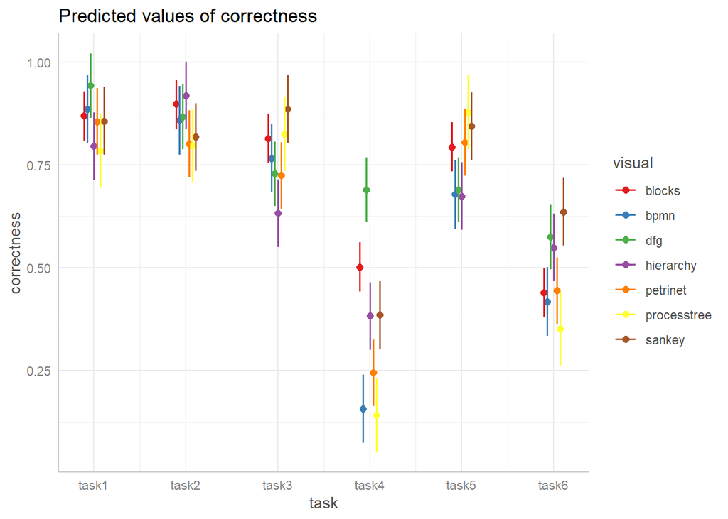

## Model 1T: use a linear model for all 6 tasks on time

multilevel linear regression on logtime per task, across tasks and visualizations, including effects of order and dataset. An estimated means plot across all conditions is provided.

|  | logtime |  |  |
| --- | --- | --- | --- |
| Predictors | Estimates | std. Error | p |
| (Intercept) | 10.83 | 0.12 | **<0.001** |
| task [task2] | 0.43 | 0.14 | **0.002** |
| task [task3] | -0.56 | 0.14 | **<0.001** |
| task [task4] | -0.24 | 0.14 | 0.090 |
| task [task5] | -0.40 | 0.14 | **0.004** |
| task [task6] | 0.54 | 0.14 | **<0.001** |
| visual [bpmn] | 0.72 | 0.18 | **<0.001** |
| visual [dfg] | -0.06 | 0.17 | 0.700 |
| visual [hierarchy] | -0.05 | 0.17 | 0.764 |
| visual [petrinet] | 0.82 | 0.17 | **<0.001** |
| visual [processtree] | 0.60 | 0.19 | **0.001** |
| visual [sankey] | 0.57 | 0.17 | **0.001** |
| order [2] | -0.38 | 0.06 | **<0.001** |
| order [3] | -0.57 | 0.06 | **<0.001** |
| order [4] | -0.76 | 0.06 | **<0.001** |
| dataset [2] | -0.07 | 0.06 | 0.234 |
| dataset [3] | -0.14 | 0.06 | **0.017** |
| dataset [4] | -0.03 | 0.06 | 0.652 |
| task [task2] × visual [bpmn] | -0.38 | 0.24 | 0.124 |
| task [task3] × visual [bpmn] | -1.07 | 0.24 | **<0.001** |
| task [task4] × visual [bpmn] | -0.43 | 0.24 | 0.078 |
| task [task5] × visual [bpmn] | -0.35 | 0.24 | 0.153 |
| task [task6] × visual [bpmn] | -0.78 | 0.24 | **0.002** |
| task [task2] × visual [dfg] | -0.06 | 0.23 | 0.797 |
| task [task3] × visual [dfg] | 0.35 | 0.23 | 0.140 |
| task [task4] × visual [dfg] | -0.10 | 0.23 | 0.672 |
| task [task5] × visual [dfg] | 0.10 | 0.23 | 0.666 |
| task [task6] × visual [dfg] | 0.49 | 0.23 | **0.036** |
| task [task2] × visual [hierarchy] | 0.14 | 0.24 | 0.574 |
| task [task3] × visual [hierarchy] | 0.49 | 0.24 | **0.043** |
| task [task4] × visual [hierarchy] | 0.20 | 0.24 | 0.403 |
| task [task5] × visual [hierarchy] | 0.06 | 0.24 | 0.795 |
| task [task6] × visual [hierarchy] | 0.02 | 0.24 | 0.947 |
| task [task2] × visual [petrinet] | -0.34 | 0.24 | 0.149 |
| task [task3] × visual [petrinet] | -0.89 | 0.24 | **<0.001** |
| task [task4] × visual [petrinet] | -0.36 | 0.24 | 0.135 |
| task [task5] × visual [petrinet] | -0.56 | 0.24 | **0.019** |
| task [task6] × visual [petrinet] | -0.74 | 0.24 | **0.002** |
| task [task2] × visual [processtree] | -0.24 | 0.26 | 0.353 |
| task [task3] × visual [processtree] | -0.89 | 0.26 | **0.001** |
| task [task4] × visual [processtree] | -0.58 | 0.26 | **0.026** |
| task [task5] × visual [processtree] | -0.41 | 0.26 | 0.114 |
| task [task6] × visual [processtree] | -0.11 | 0.26 | 0.665 |
| task [task2] × visual [sankey] | -0.10 | 0.24 | 0.677 |
| task [task3] × visual [sankey] | -0.33 | 0.24 | 0.172 |
| task [task4] × visual [sankey] | -0.88 | 0.24 | **<0.001** |
| task [task5] × visual [sankey] | -0.23 | 0.24 | 0.346 |
| task [task6] × visual [sankey] | -0.80 | 0.24 | **0.001** |
| Random Effects |  |  |  |
| σ<sup>2</sup> | 0.46 |  |  |
| τ<sub>00</sub> <sub>p_id</sub> | 0.15 |  |  |
| ICC | 0.24 |  |  |
| N <sub>p_id</sub> | 48 |  |  |
| Observations | 1134 |  |  |
| Marginal R<sup>2</sup> / Conditional R<sup>2</sup> | 0.346 / 0.506 |  |  |

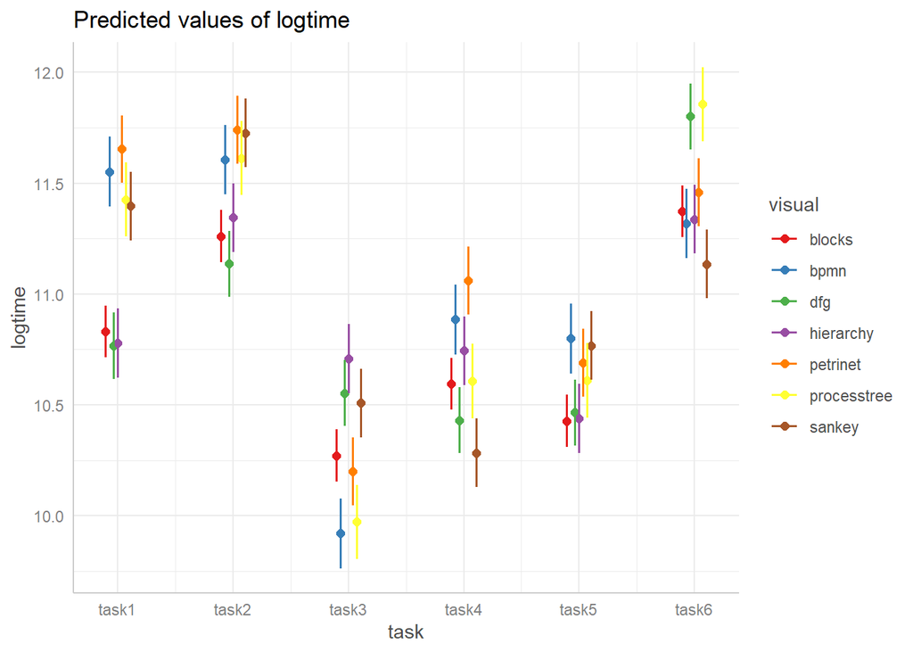

## Model 2: correctness per visualization (across tasks)

Multilevel linear regression on correctness with main effect of visualization (across tasks) and the estimated pair-wise means to compare between the different visualizations. Second model adds pmexH (process mining expertise, high (4 and 5) vs. low (1-3) ) as an interaction factor

|  | correctness |  |  |
| --- | --- | --- | --- |
| Predictors | Estimates | std. Error | p |
| (Intercept) | 0.72 | 0.03 | **<0.001** |
| visual [bpmn] | -0.10 | 0.05 | **0.025** |
| visual [dfg] | 0.03 | 0.04 | 0.499 |
| visual [hierarchy] | -0.07 | 0.04 | 0.124 |
| visual [petrinet] | -0.08 | 0.04 | 0.078 |
| visual [processtree] | -0.08 | 0.05 | 0.087 |
| visual [sankey] | 0.01 | 0.04 | 0.792 |
| Random Effects |  |  |  |
| σ<sup>2</sup> | 0.19 |  |  |
| τ<sub>00</sub> <sub>p_id</sub> | 0.00 |  |  |
| ICC | 0.02 |  |  |
| N <sub>p_id</sub> | 48 |  |  |
| Observations | 1134 |  |  |
| Marginal R<sup>2</sup> / Conditional R<sup>2</sup> | 0.012 / 0.032 |  |  |

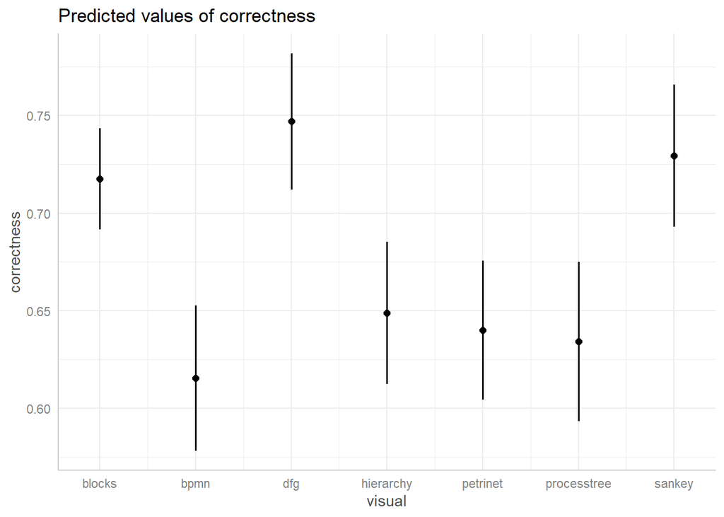

| term | levels | Estimate | Std. Error | df | t value | lower | upper | Pr(>\|t\|) |
| --- | --- | --- | --- | --- | --- | --- | --- | --- |
| visual | blocks - bpmn | 0.10 | 0.05 | 1109.72 | 2.25 | 0.01 | 0.19 | 0.02 |
| visual | blocks - dfg | -0.03 | 0.04 | 1120.90 | -0.68 | -0.11 | 0.06 | 0.50 |
| visual | blocks - hierarchy | 0.07 | 0.04 | 1109.12 | 1.54 | -0.02 | 0.16 | 0.12 |
| visual | blocks - petrinet | 0.08 | 0.04 | 1118.40 | 1.76 | -8.84e-03 | 0.16 | 0.08 |
| visual | blocks - processtree | 0.08 | 0.05 | 1083.17 | 1.71 | -0.01 | 0.18 | 0.09 |
| visual | blocks - sankey | -0.01 | 0.04 | 1109.12 | -0.26 | -0.10 | 0.08 | 0.79 |
| visual | bpmn - dfg | -0.13 | 0.05 | 957.55 | -2.53 | -0.23 | -0.03 | 0.01 |
| visual | bpmn - hierarchy | -0.03 | 0.05 | 1000.28 | -0.63 | -0.14 | 0.07 | 0.53 |
| visual | bpmn - petrinet | -0.02 | 0.05 | 1022.03 | -0.47 | -0.13 | 0.08 | 0.64 |
| visual | bpmn - processtree | -0.02 | 0.06 | 905.63 | -0.33 | -0.13 | 0.09 | 0.74 |
| visual | bpmn - sankey | -0.11 | 0.05 | 1078.61 | -2.17 | -0.22 | -0.01 | 0.03 |
| visual | dfg - hierarchy | 0.10 | 0.05 | 1080.60 | 1.93 | -1.52e-03 | 0.20 | 0.05 |
| visual | dfg - petrinet | 0.11 | 0.05 | 950.22 | 2.10 | 7.23e-03 | 0.21 | 0.04 |
| visual | dfg - processtree | 0.11 | 0.05 | 949.51 | 2.06 | 5.29e-03 | 0.22 | 0.04 |
| visual | dfg - sankey | 0.02 | 0.05 | 1029.58 | 0.35 | -0.08 | 0.12 | 0.73 |
| visual | hierarchy - petrinet | 8.77e-03 | 0.05 | 1038.77 | 0.17 | -0.09 | 0.11 | 0.86 |
| visual | hierarchy - processtree | 0.01 | 0.06 | 1001.01 | 0.26 | -0.09 | 0.12 | 0.79 |
| visual | hierarchy - sankey | -0.08 | 0.05 | 721.70 | -1.52 | -0.18 | 0.02 | 0.13 |
| visual | petrinet - processtree | 5.79e-03 | 0.06 | 960.08 | 0.10 | -0.10 | 0.11 | 0.92 |
| visual | petrinet - sankey | -0.09 | 0.05 | 1067.12 | -1.74 | -0.19 | 0.01 | 0.08 |
| visual | processtree - sankey | -0.10 | 0.06 | 1034.37 | -1.72 | -0.20 | 0.01 | 0.09 |

```
## Linear mixed model fit by REML. t-tests use Satterthwaite's method [
## lmerModLmerTest]
## Formula: correctness ~ visual * pmexH + (1 | p_id)
##    Data: dtcor
##
## REML criterion at convergence: 1374.8
##
## Scaled residuals:
##     Min      1Q  Median      3Q     Max
## -2.0023 -1.3460  0.5374  0.7131  1.1139
##
## Random effects:
##  Groups   Name        Variance Std.Dev.
##  p_id     (Intercept) 0.004337 0.06586
##  Residual             0.185992 0.43127
## Number of obs: 1134, groups:  p_id, 48
##
## Fixed effects:
##                           Estimate Std. Error         df t value Pr(>|t|)
## (Intercept)                0.74049    0.03618  313.38109  20.469   <2e-16 ***
## visualbpmn                -0.13563    0.06662 1063.68524  -2.036   0.0420 *
## visualdfg                 -0.02921    0.05510 1119.98712  -0.530   0.5961
## visualhierarchy           -0.06277    0.06046 1098.11502  -1.038   0.2994
## visualpetrinet            -0.09164    0.06043 1103.91940  -1.517   0.1297
## visualprocesstree         -0.12712    0.06043 1102.96414  -2.103   0.0357 *
## visualsankey              -0.04683    0.05889 1106.82428  -0.795   0.4266
## pmexH                     -0.05240    0.05469  313.38109  -0.958   0.3388
## visualbpmn:pmexH           0.07346    0.09158 1101.58769   0.802   0.4226
## visualdfg:pmexH            0.15261    0.09029 1103.08825   1.690   0.0913 .
## visualhierarchy:pmexH     -0.01009    0.08991 1102.69352  -0.112   0.9107
## visualpetrinet:pmexH       0.03561    0.08842 1112.32912   0.403   0.6872
## visualprocesstree:pmexH    0.11385    0.10324 1049.85682   1.103   0.2703
## visualsankey:pmexH         0.13731    0.09059 1099.88408   1.516   0.1299
## ---
## Signif. codes:  0 '***' 0.001 '**' 0.01 '*' 0.05 '.' 0.1 ' ' 1
```

```
##
## Correlation matrix not shown by default, as p = 14 > 12.
## Use print(x, correlation=TRUE)  or
##     vcov(x)        if you need it
```

|  | correctness |  |  |
| --- | --- | --- | --- |
| Predictors | Estimates | std. Error | p |
| (Intercept) | 0.74 | 0.04 | **<0.001** |
| visual [bpmn] | -0.14 | 0.07 | **0.042** |
| visual [dfg] | -0.03 | 0.06 | 0.596 |
| visual [hierarchy] | -0.06 | 0.06 | 0.299 |
| visual [petrinet] | -0.09 | 0.06 | 0.130 |
| visual [processtree] | -0.13 | 0.06 | **0.036** |
| visual [sankey] | -0.05 | 0.06 | 0.427 |
| pmexH | -0.05 | 0.05 | 0.338 |
| visual [bpmn] × pmexH | 0.07 | 0.09 | 0.423 |
| visual [dfg] × pmexH | 0.15 | 0.09 | 0.091 |
| visual [hierarchy] × pmexH | -0.01 | 0.09 | 0.911 |
| visual [petrinet] × pmexH | 0.04 | 0.09 | 0.687 |
| visual [processtree] × pmexH | 0.11 | 0.10 | 0.270 |
| visual [sankey] × pmexH | 0.14 | 0.09 | 0.130 |
| Random Effects |  |  |  |
| σ<sup>2</sup> | 0.19 |  |  |
| τ<sub>00</sub> <sub>p_id</sub> | 0.00 |  |  |
| ICC | 0.02 |  |  |
| N <sub>p_id</sub> | 48 |  |  |
| Observations | 1134 |  |  |
| Marginal R<sup>2</sup> / Conditional R<sup>2</sup> | 0.017 / 0.039 |  |  |

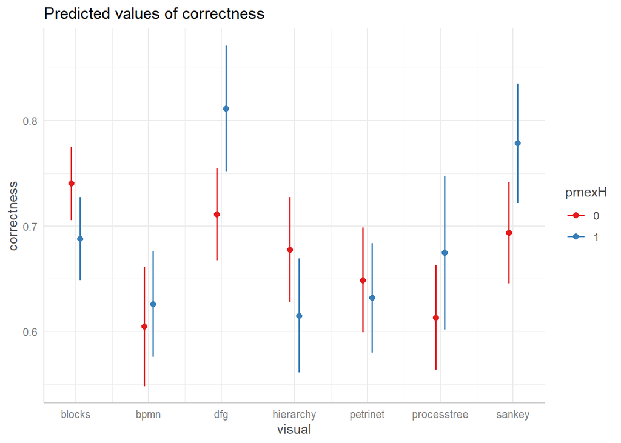

## Model 2T: time per visualization (across tasks)

Multilevel linear regression on logtime with main effect of visualization (across tasks) and the estimated pair-wise means to compare between the different visualizations added pmexH (expertise) as an interaction factor

|  | logtime |  |  |
| --- | --- | --- | --- |
| Predictors | Estimates | std. Error | p |
| (Intercept) | 10.40 | 0.07 | **<0.001** |
| visual [bpmn] | 0.15 | 0.10 | 0.127 |
| visual [dfg] | 0.01 | 0.09 | 0.921 |
| visual [hierarchy] | -0.06 | 0.09 | 0.506 |
| visual [petrinet] | 0.11 | 0.09 | 0.232 |
| visual [processtree] | 0.21 | 0.10 | **0.040** |
| visual [sankey] | 0.01 | 0.09 | 0.932 |
| Random Effects |  |  |  |
| σ<sup>2</sup> | 0.78 |  |  |
| τ<sub>00</sub> <sub>p_id</sub> | 0.13 |  |  |
| ICC | 0.15 |  |  |
| N <sub>p_id</sub> | 48 |  |  |
| Observations | 1134 |  |  |
| Marginal R<sup>2</sup> / Conditional R<sup>2</sup> | 0.008 / 0.152 |  |  |

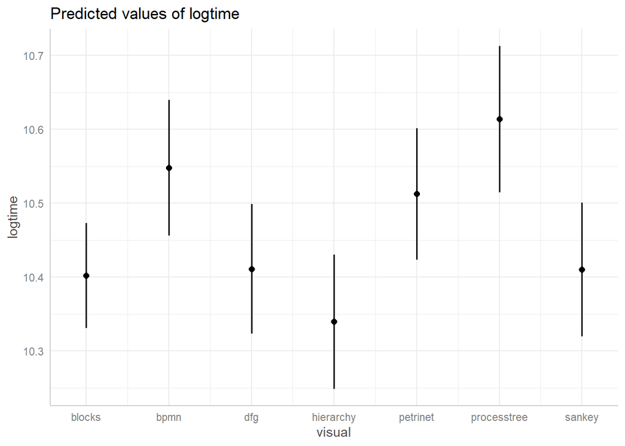

| term | levels | Estimate | Std. Error | df | t value | lower | upper | Pr(>\|t\|) |
| --- | --- | --- | --- | --- | --- | --- | --- | --- |
| visual | blocks - bpmn | -0.15 | 0.10 | 1116.71 | -1.53 | -0.33 | 0.04 | 0.13 |
| visual | blocks - dfg | -8.97e-03 | 0.09 | 1113.12 | -0.10 | -0.19 | 0.17 | 0.92 |
| visual | blocks - hierarchy | 0.06 | 0.09 | 1119.30 | 0.66 | -0.12 | 0.25 | 0.51 |
| visual | blocks - petrinet | -0.11 | 0.09 | 1113.69 | -1.20 | -0.29 | 0.07 | 0.23 |
| visual | blocks - processtree | -0.21 | 0.10 | 1121.25 | -2.06 | -0.41 | -0.01 | 0.04 |
| visual | blocks - sankey | -7.98e-03 | 0.09 | 1119.30 | -0.08 | -0.19 | 0.18 | 0.93 |
| visual | bpmn - dfg | 0.14 | 0.11 | 1127.00 | 1.23 | -0.08 | 0.36 | 0.22 |
| visual | bpmn - hierarchy | 0.21 | 0.11 | 1126.94 | 1.85 | -0.01 | 0.43 | 0.07 |
| visual | bpmn - petrinet | 0.04 | 0.11 | 1124.83 | 0.32 | -0.18 | 0.25 | 0.75 |
| visual | bpmn - processtree | -0.07 | 0.12 | 1126.73 | -0.54 | -0.30 | 0.17 | 0.59 |
| visual | bpmn - sankey | 0.14 | 0.11 | 1121.63 | 1.24 | -0.08 | 0.35 | 0.21 |
| visual | dfg - hierarchy | 0.07 | 0.11 | 1121.54 | 0.67 | -0.14 | 0.28 | 0.51 |
| visual | dfg - petrinet | -0.10 | 0.11 | 1127.00 | -0.93 | -0.32 | 0.11 | 0.35 |
| visual | dfg - processtree | -0.20 | 0.12 | 1127.00 | -1.72 | -0.43 | 0.03 | 0.08 |
| visual | dfg - sankey | 9.98e-04 | 0.11 | 1126.55 | 9.18e-03 | -0.21 | 0.21 | 0.99 |
| visual | hierarchy - petrinet | -0.17 | 0.11 | 1125.99 | -1.58 | -0.39 | 0.04 | 0.11 |
| visual | hierarchy - processtree | -0.27 | 0.12 | 1126.83 | -2.31 | -0.51 | -0.04 | 0.02 |
| visual | hierarchy - sankey | -0.07 | 0.12 | 1111.56 | -0.60 | -0.30 | 0.16 | 0.55 |
| visual | petrinet - processtree | -0.10 | 0.12 | 1126.87 | -0.86 | -0.33 | 0.13 | 0.39 |
| visual | petrinet - sankey | 0.10 | 0.11 | 1123.10 | 0.94 | -0.11 | 0.32 | 0.35 |
| visual | processtree - sankey | 0.20 | 0.12 | 1125.34 | 1.73 | -0.03 | 0.43 | 0.08 |

```
## Linear mixed model fit by REML. t-tests use Satterthwaite's method [
## lmerModLmerTest]
## Formula: logtime ~ visual * pmexH + (1 | p_id)
##    Data: dttime
##
## REML criterion at convergence: 3033.9
##
## Scaled residuals:
##     Min      1Q  Median      3Q     Max
## -5.7607 -0.5681  0.0486  0.6508  5.1933
##
## Random effects:
##  Groups   Name        Variance Std.Dev.
##  p_id     (Intercept) 0.1198   0.3461
##  Residual             0.7830   0.8848
## Number of obs: 1134, groups:  p_id, 48
##
## Fixed effects:
##                           Estimate Std. Error         df t value Pr(>|t|)
## (Intercept)               10.52830    0.09628  119.58613 109.354   <2e-16 ***
## visualbpmn                -0.01824    0.14083 1118.12180  -0.130    0.897
## visualdfg                 -0.02224    0.11468 1101.94713  -0.194    0.846
## visualhierarchy           -0.12623    0.12714 1115.22290  -0.993    0.321
## visualpetrinet             0.16583    0.12677 1112.07119   1.308    0.191
## visualprocesstree          0.18070    0.12684 1112.66482   1.425    0.155
## visualsankey               0.01882    0.12357 1113.27417   0.152    0.879
## pmexH                     -0.28826    0.14556  119.58613  -1.980    0.050 *
## visualbpmn:pmexH           0.30657    0.19230 1113.37487   1.594    0.111
## visualdfg:pmexH            0.05860    0.18967 1114.48105   0.309    0.757
## visualhierarchy:pmexH      0.15051    0.18893 1114.87184   0.797    0.426
## visualpetrinet:pmexH      -0.10949    0.18504 1109.56735  -0.592    0.554
## visualprocesstree:pmexH    0.08315    0.21873 1119.20972   0.380    0.704
## visualsankey:pmexH        -0.03864    0.19050 1115.52833  -0.203    0.839
## ---
## Signif. codes:  0 '***' 0.001 '**' 0.01 '*' 0.05 '.' 0.1 ' ' 1
```

```
##
## Correlation matrix not shown by default, as p = 14 > 12.
## Use print(x, correlation=TRUE)  or
##     vcov(x)        if you need it
```

|  | logtime |  |  |
| --- | --- | --- | --- |
| Predictors | Estimates | std. Error | p |
| (Intercept) | 10.53 | 0.10 | **<0.001** |
| visual [bpmn] | -0.02 | 0.14 | 0.897 |
| visual [dfg] | -0.02 | 0.11 | 0.846 |
| visual [hierarchy] | -0.13 | 0.13 | 0.321 |
| visual [petrinet] | 0.17 | 0.13 | 0.191 |
| visual [processtree] | 0.18 | 0.13 | 0.155 |
| visual [sankey] | 0.02 | 0.12 | 0.879 |
| pmexH | -0.29 | 0.15 | **0.048** |
| visual [bpmn] × pmexH | 0.31 | 0.19 | 0.111 |
| visual [dfg] × pmexH | 0.06 | 0.19 | 0.757 |
| visual [hierarchy] × pmexH | 0.15 | 0.19 | 0.426 |
| visual [petrinet] × pmexH | -0.11 | 0.19 | 0.554 |
| visual [processtree] × pmexH | 0.08 | 0.22 | 0.704 |
| visual [sankey] × pmexH | -0.04 | 0.19 | 0.839 |
| Random Effects |  |  |  |
| σ<sup>2</sup> | 0.78 |  |  |
| τ<sub>00</sub> <sub>p_id</sub> | 0.12 |  |  |
| ICC | 0.13 |  |  |
| N <sub>p_id</sub> | 48 |  |  |
| Observations | 1134 |  |  |
| Marginal R<sup>2</sup> / Conditional R<sup>2</sup> | 0.026 / 0.155 |  |  |

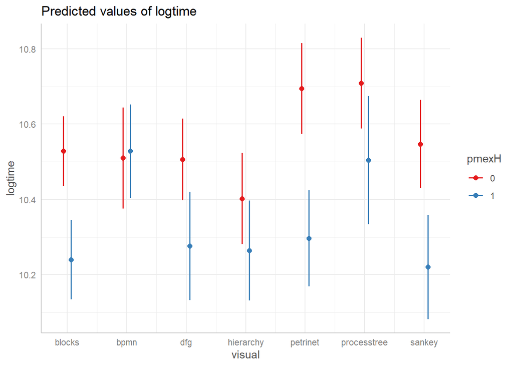

## Model 3: Per task

Multilevel linear regression models on correctness per task to test for effects of visualization per task, with pairwise differences reported for comparisons

### Model 3a: task 1

|  | correctness |  |  |
| --- | --- | --- | --- |
| Predictors | Estimates | std. Error | p |
| (Intercept) | 0.87 | 0.02 | **<0.001** |
| visual [bpmn] | -0.00 | 0.04 | 0.908 |
| visual [dfg] | 0.08 | 0.04 | **0.033** |
| visual [hierarchy] | -0.07 | 0.04 | 0.086 |
| visual [petrinet] | -0.02 | 0.04 | 0.553 |
| visual [processtree] | -0.08 | 0.04 | 0.073 |
| visual [sankey] | -0.03 | 0.04 | 0.441 |
| Random Effects |  |  |  |
| σ<sup>2</sup> | 0.03 |  |  |
| τ<sub>00</sub> <sub>p_id</sub> | 0.00 |  |  |
| ICC | 0.14 |  |  |
| N <sub>p_id</sub> | 48 |  |  |
| Observations | 189 |  |  |
| Marginal R<sup>2</sup> / Conditional R<sup>2</sup> | 0.072 / 0.202 |  |  |

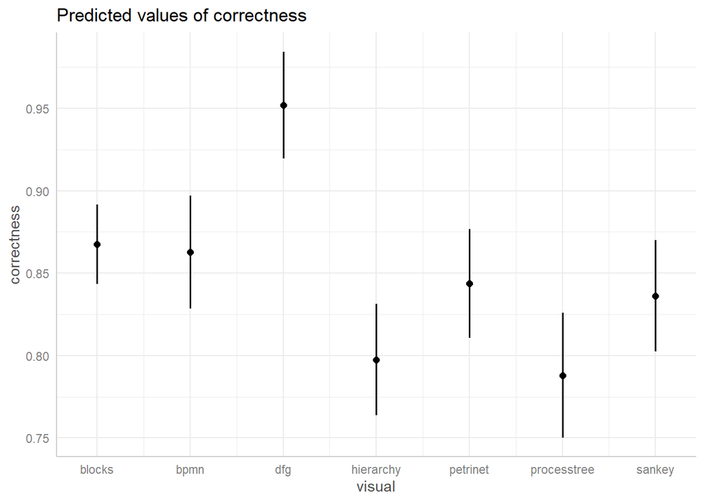

| term | levels | Estimate | Std. Error | df | t value | lower | upper | Pr(>\|t\|) |
| --- | --- | --- | --- | --- | --- | --- | --- | --- |
| visual | blocks - bpmn | 4.74e-03 | 0.04 | 147.24 | 0.12 | -0.08 | 0.09 | 0.91 |
| visual | blocks - dfg | -0.08 | 0.04 | 144.61 | -2.15 | -0.16 | -6.71e-03 | 0.03 |
| visual | blocks - hierarchy | 0.07 | 0.04 | 147.56 | 1.73 | -0.01 | 0.15 | 0.09 |
| visual | blocks - petrinet | 0.02 | 0.04 | 145.30 | 0.59 | -0.06 | 0.10 | 0.55 |
| visual | blocks - processtree | 0.08 | 0.04 | 151.13 | 1.80 | -7.72e-03 | 0.17 | 0.07 |
| visual | blocks - sankey | 0.03 | 0.04 | 147.56 | 0.77 | -0.05 | 0.11 | 0.44 |
| visual | bpmn - dfg | -0.09 | 0.05 | 161.67 | -1.89 | -0.18 | 3.91e-03 | 0.06 |
| visual | bpmn - hierarchy | 0.07 | 0.05 | 158.93 | 1.36 | -0.03 | 0.16 | 0.17 |
| visual | bpmn - petrinet | 0.02 | 0.05 | 156.83 | 0.40 | -0.07 | 0.11 | 0.69 |
| visual | bpmn - processtree | 0.07 | 0.05 | 164.83 | 1.46 | -0.03 | 0.18 | 0.15 |
| visual | bpmn - sankey | 0.03 | 0.05 | 151.65 | 0.56 | -0.07 | 0.12 | 0.58 |
| visual | dfg - hierarchy | 0.15 | 0.05 | 151.44 | 3.35 | 0.06 | 0.25 | 1.02e-03 |
| visual | dfg - petrinet | 0.11 | 0.05 | 162.14 | 2.34 | 0.02 | 0.20 | 0.02 |
| visual | dfg - processtree | 0.16 | 0.05 | 162.17 | 3.29 | 0.07 | 0.26 | 1.21e-03 |
| visual | dfg - sankey | 0.12 | 0.05 | 156.66 | 2.50 | 0.02 | 0.21 | 0.01 |
| visual | hierarchy - petrinet | -0.05 | 0.05 | 155.81 | -0.99 | -0.14 | 0.05 | 0.32 |
| visual | hierarchy - processtree | 9.47e-03 | 0.05 | 158.80 | 0.19 | -0.09 | 0.11 | 0.85 |
| visual | hierarchy - sankey | -0.04 | 0.05 | 174.57 | -0.80 | -0.13 | 0.06 | 0.43 |
| visual | petrinet - processtree | 0.06 | 0.05 | 161.39 | 1.11 | -0.04 | 0.15 | 0.27 |
| visual | petrinet - sankey | 7.55e-03 | 0.05 | 152.94 | 0.16 | -0.08 | 0.10 | 0.87 |
| visual | processtree - sankey | -0.05 | 0.05 | 156.02 | -0.96 | -0.15 | 0.05 | 0.34 |

### Model 3b: task 2

```
## boundary (singular) fit: see help('isSingular')
```

|  | correctness |  |  |
| --- | --- | --- | --- |
| Predictors | Estimates | std. Error | p |
| (Intercept) | 0.90 | 0.04 | **<0.001** |
| visual [bpmn] | -0.06 | 0.07 | 0.331 |
| visual [dfg] | -0.03 | 0.06 | 0.674 |
| visual [hierarchy] | 0.01 | 0.06 | 0.817 |
| visual [petrinet] | -0.10 | 0.06 | 0.122 |
| visual [processtree] | -0.08 | 0.07 | 0.242 |
| visual [sankey] | -0.09 | 0.06 | 0.171 |
| Random Effects |  |  |  |
| σ<sup>2</sup> | 0.07 |  |  |
| τ<sub>00</sub> <sub>p_id</sub> | 0.00 |  |  |
| N <sub>p_id</sub> | 48 |  |  |
| Observations | 189 |  |  |
| Marginal R<sup>2</sup> / Conditional R<sup>2</sup> | 0.027 / NA |  |  |

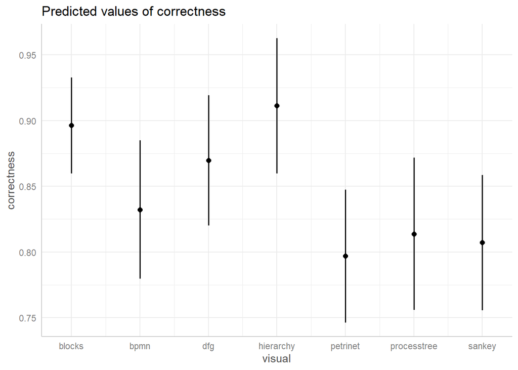

| term | levels | Estimate | Std. Error | df | t value | lower | upper | Pr(>\|t\|) |
| --- | --- | --- | --- | --- | --- | --- | --- | --- |
| visual | blocks - bpmn | 0.06 | 0.07 | 182.00 | 0.97 | -0.07 | 0.19 | 0.33 |
| visual | blocks - dfg | 0.03 | 0.06 | 182.00 | 0.42 | -0.10 | 0.15 | 0.67 |
| visual | blocks - hierarchy | -0.01 | 0.06 | 182.00 | -0.23 | -0.14 | 0.11 | 0.82 |
| visual | blocks - petrinet | 0.10 | 0.06 | 182.00 | 1.55 | -0.03 | 0.23 | 0.12 |
| visual | blocks - processtree | 0.08 | 0.07 | 182.00 | 1.17 | -0.06 | 0.22 | 0.24 |
| visual | blocks - sankey | 0.09 | 0.06 | 182.00 | 1.37 | -0.04 | 0.22 | 0.17 |
| visual | bpmn - dfg | -0.04 | 0.07 | 182.00 | -0.50 | -0.18 | 0.11 | 0.61 |
| visual | bpmn - hierarchy | -0.08 | 0.08 | 182.00 | -1.04 | -0.23 | 0.07 | 0.30 |
| visual | bpmn - petrinet | 0.04 | 0.07 | 182.00 | 0.47 | -0.11 | 0.18 | 0.64 |
| visual | bpmn - processtree | 0.02 | 0.08 | 182.00 | 0.23 | -0.14 | 0.18 | 0.82 |
| visual | bpmn - sankey | 0.03 | 0.08 | 182.00 | 0.33 | -0.12 | 0.17 | 0.74 |
| visual | dfg - hierarchy | -0.04 | 0.07 | 182.00 | -0.57 | -0.19 | 0.10 | 0.57 |
| visual | dfg - petrinet | 0.07 | 0.07 | 182.00 | 1.00 | -0.07 | 0.22 | 0.32 |
| visual | dfg - processtree | 0.06 | 0.08 | 182.00 | 0.71 | -0.10 | 0.21 | 0.48 |
| visual | dfg - sankey | 0.06 | 0.07 | 182.00 | 0.85 | -0.08 | 0.21 | 0.40 |
| visual | hierarchy - petrinet | 0.11 | 0.07 | 182.00 | 1.54 | -0.03 | 0.26 | 0.12 |
| visual | hierarchy - processtree | 0.10 | 0.08 | 182.00 | 1.22 | -0.06 | 0.25 | 0.22 |
| visual | hierarchy - sankey | 0.10 | 0.07 | 182.00 | 1.39 | -0.04 | 0.25 | 0.17 |
| visual | petrinet - processtree | -0.02 | 0.08 | 182.00 | -0.21 | -0.17 | 0.14 | 0.83 |
| visual | petrinet - sankey | -0.01 | 0.07 | 182.00 | -0.14 | -0.16 | 0.14 | 0.89 |
| visual | processtree - sankey | 6.60e-03 | 0.08 | 182.00 | 0.08 | -0.15 | 0.16 | 0.93 |

### Model 3c: task 3

|  | correctness |  |  |
| --- | --- | --- | --- |
| Predictors | Estimates | std. Error | p |
| (Intercept) | 0.81 | 0.06 | **<0.001** |
| visual [bpmn] | -0.05 | 0.10 | 0.623 |
| visual [dfg] | -0.09 | 0.10 | 0.342 |
| visual [hierarchy] | -0.18 | 0.10 | 0.069 |
| visual [petrinet] | -0.10 | 0.10 | 0.301 |
| visual [processtree] | 0.02 | 0.11 | 0.848 |
| visual [sankey] | 0.06 | 0.10 | 0.575 |
| Random Effects |  |  |  |
| σ<sup>2</sup> | 0.15 |  |  |
| τ<sub>00</sub> <sub>p_id</sub> | 0.03 |  |  |
| ICC | 0.17 |  |  |
| N <sub>p_id</sub> | 48 |  |  |
| Observations | 189 |  |  |
| Marginal R<sup>2</sup> / Conditional R<sup>2</sup> | 0.029 / 0.196 |  |  |

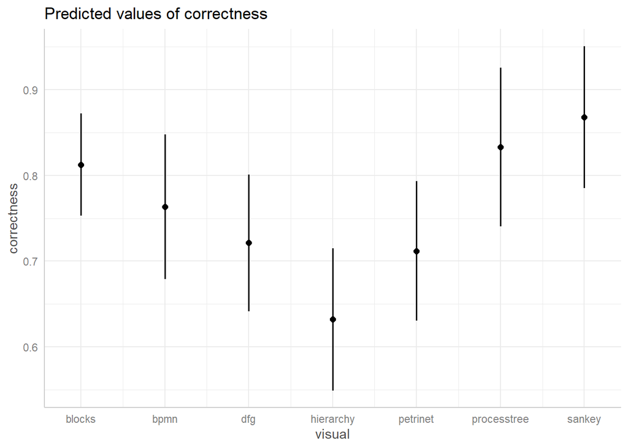

| term | levels | Estimate | Std. Error | df | t value | lower | upper | Pr(>\|t\|) |
| --- | --- | --- | --- | --- | --- | --- | --- | --- |
| visual | blocks - bpmn | 0.05 | 0.10 | 149.27 | 0.49 | -0.15 | 0.25 | 0.62 |
| visual | blocks - dfg | 0.09 | 0.10 | 147.04 | 0.95 | -0.10 | 0.28 | 0.34 |
| visual | blocks - hierarchy | 0.18 | 0.10 | 149.73 | 1.83 | -0.01 | 0.38 | 0.07 |
| visual | blocks - petrinet | 0.10 | 0.10 | 147.60 | 1.04 | -0.09 | 0.29 | 0.30 |
| visual | blocks - processtree | -0.02 | 0.11 | 152.59 | -0.19 | -0.23 | 0.19 | 0.85 |
| visual | blocks - sankey | -0.06 | 0.10 | 149.73 | -0.56 | -0.25 | 0.14 | 0.57 |
| visual | bpmn - dfg | 0.04 | 0.12 | 161.58 | 0.36 | -0.19 | 0.27 | 0.72 |
| visual | bpmn - hierarchy | 0.13 | 0.12 | 159.44 | 1.12 | -0.10 | 0.36 | 0.26 |
| visual | bpmn - petrinet | 0.05 | 0.12 | 157.28 | 0.45 | -0.18 | 0.28 | 0.66 |
| visual | bpmn - processtree | -0.07 | 0.13 | 164.23 | -0.56 | -0.32 | 0.18 | 0.58 |
| visual | bpmn - sankey | -0.10 | 0.12 | 153.01 | -0.90 | -0.33 | 0.12 | 0.37 |
| visual | dfg - hierarchy | 0.09 | 0.11 | 152.85 | 0.80 | -0.13 | 0.31 | 0.43 |
| visual | dfg - petrinet | 9.46e-03 | 0.11 | 161.97 | 0.08 | -0.21 | 0.23 | 0.93 |
| visual | dfg - processtree | -0.11 | 0.12 | 161.98 | -0.92 | -0.35 | 0.13 | 0.36 |
| visual | dfg - sankey | -0.15 | 0.11 | 157.54 | -1.30 | -0.37 | 0.08 | 0.20 |
| visual | hierarchy - petrinet | -0.08 | 0.11 | 156.75 | -0.70 | -0.30 | 0.15 | 0.48 |
| visual | hierarchy - processtree | -0.20 | 0.12 | 159.26 | -1.64 | -0.44 | 0.04 | 0.10 |
| visual | hierarchy - sankey | -0.24 | 0.12 | 173.14 | -1.99 | -0.47 | -2.10e-03 | 0.05 |
| visual | petrinet - processtree | -0.12 | 0.12 | 161.23 | -0.99 | -0.36 | 0.12 | 0.32 |
| visual | petrinet - sankey | -0.16 | 0.11 | 154.15 | -1.37 | -0.38 | 0.07 | 0.17 |
| visual | processtree - sankey | -0.03 | 0.12 | 156.78 | -0.28 | -0.28 | 0.21 | 0.78 |

### Model 3d: task 4

|  | correctness |  |  |
| --- | --- | --- | --- |
| Predictors | Estimates | std. Error | p |
| (Intercept) | 0.50 | 0.07 | **<0.001** |
| visual [bpmn] | -0.37 | 0.12 | **0.002** |
| visual [dfg] | 0.19 | 0.11 | 0.092 |
| visual [hierarchy] | -0.12 | 0.11 | 0.300 |
| visual [petrinet] | -0.26 | 0.11 | **0.021** |
| visual [processtree] | -0.34 | 0.12 | **0.007** |
| visual [sankey] | -0.13 | 0.11 | 0.247 |
| Random Effects |  |  |  |
| σ<sup>2</sup> | 0.20 |  |  |
| τ<sub>00</sub> <sub>p_id</sub> | 0.01 |  |  |
| ICC | 0.03 |  |  |
| N <sub>p_id</sub> | 48 |  |  |
| Observations | 189 |  |  |
| Marginal R<sup>2</sup> / Conditional R<sup>2</sup> | 0.130 / 0.160 |  |  |

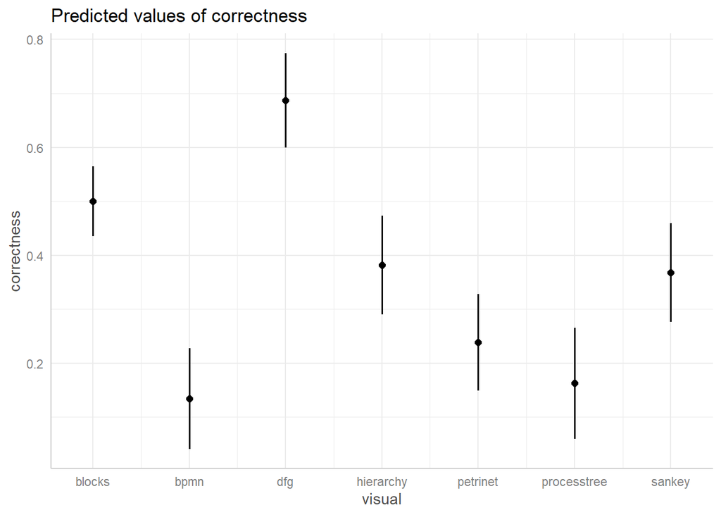

| term | levels | Estimate | Std. Error | df | t value | lower | upper | Pr(>\|t\|) |
| --- | --- | --- | --- | --- | --- | --- | --- | --- |
| visual | blocks - bpmn | 0.37 | 0.12 | 156.74 | 3.17 | 0.14 | 0.59 | 1.82e-03 |
| visual | blocks - dfg | -0.19 | 0.11 | 153.55 | -1.69 | -0.41 | 0.03 | 0.09 |
| visual | blocks - hierarchy | 0.12 | 0.11 | 156.07 | 1.04 | -0.11 | 0.34 | 0.30 |
| visual | blocks - petrinet | 0.26 | 0.11 | 154.54 | 2.33 | 0.04 | 0.48 | 0.02 |
| visual | blocks - processtree | 0.34 | 0.12 | 161.27 | 2.74 | 0.09 | 0.58 | 6.91e-03 |
| visual | blocks - sankey | 0.13 | 0.11 | 156.07 | 1.16 | -0.09 | 0.36 | 0.25 |
| visual | bpmn - dfg | -0.55 | 0.13 | 172.66 | -4.23 | -0.81 | -0.29 | 3.80e-05 |
| visual | bpmn - hierarchy | -0.25 | 0.13 | 168.82 | -1.86 | -0.51 | 0.02 | 0.06 |
| visual | bpmn - petrinet | -0.10 | 0.13 | 168.48 | -0.79 | -0.36 | 0.16 | 0.43 |
| visual | bpmn - processtree | -0.03 | 0.14 | 175.82 | -0.20 | -0.31 | 0.25 | 0.84 |
| visual | bpmn - sankey | -0.23 | 0.13 | 161.97 | -1.76 | -0.50 | 0.03 | 0.08 |
| visual | dfg - hierarchy | 0.31 | 0.13 | 161.64 | 2.37 | 0.05 | 0.56 | 0.02 |
| visual | dfg - petrinet | 0.45 | 0.13 | 173.15 | 3.51 | 0.20 | 0.70 | 5.78e-04 |
| visual | dfg - processtree | 0.52 | 0.14 | 173.23 | 3.81 | 0.25 | 0.80 | 1.96e-04 |
| visual | dfg - sankey | 0.32 | 0.13 | 166.25 | 2.48 | 0.06 | 0.57 | 0.01 |
| visual | hierarchy - petrinet | 0.14 | 0.13 | 165.64 | 1.10 | -0.11 | 0.40 | 0.27 |
| visual | hierarchy - processtree | 0.22 | 0.14 | 169.01 | 1.57 | -0.06 | 0.50 | 0.12 |
| visual | hierarchy - sankey | 0.01 | 0.13 | 181.44 | 0.11 | -0.25 | 0.28 | 0.92 |
| visual | petrinet - processtree | 0.08 | 0.14 | 172.83 | 0.55 | -0.20 | 0.35 | 0.59 |
| visual | petrinet - sankey | -0.13 | 0.13 | 163.25 | -0.99 | -0.39 | 0.13 | 0.32 |
| visual | processtree - sankey | -0.21 | 0.14 | 166.60 | -1.47 | -0.48 | 0.07 | 0.14 |

### Model 3e: task 5

|  | correctness |  |  |
| --- | --- | --- | --- |
| Predictors | Estimates | std. Error | p |
| (Intercept) | 0.79 | 0.06 | **<0.001** |
| visual [bpmn] | -0.14 | 0.11 | 0.201 |
| visual [dfg] | -0.10 | 0.10 | 0.339 |
| visual [hierarchy] | -0.13 | 0.11 | 0.238 |
| visual [petrinet] | 0.01 | 0.11 | 0.938 |
| visual [processtree] | 0.10 | 0.12 | 0.377 |
| visual [sankey] | 0.04 | 0.11 | 0.689 |
| Random Effects |  |  |  |
| σ<sup>2</sup> | 0.18 |  |  |
| τ<sub>00</sub> <sub>p_id</sub> | 0.00 |  |  |
| ICC | 0.00 |  |  |
| N <sub>p_id</sub> | 48 |  |  |
| Observations | 189 |  |  |
| Marginal R<sup>2</sup> / Conditional R<sup>2</sup> | 0.033 / 0.037 |  |  |

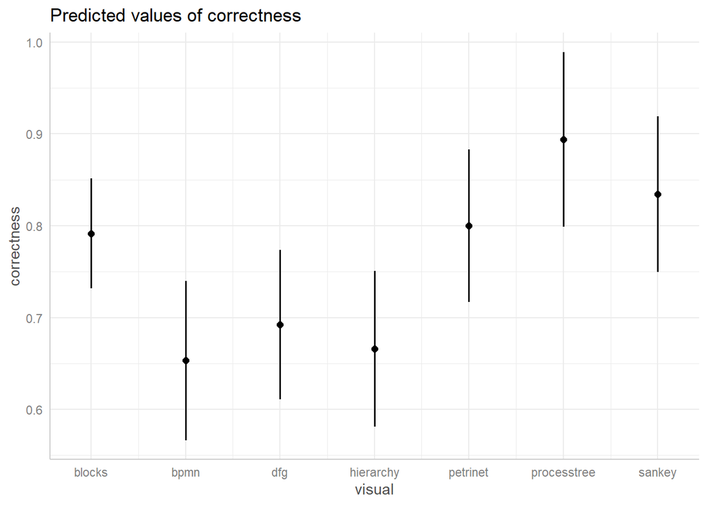

| term | levels | Estimate | Std. Error | df | t value | lower | upper | Pr(>\|t\|) |
| --- | --- | --- | --- | --- | --- | --- | --- | --- |
| visual | blocks - bpmn | 0.14 | 0.11 | 158.24 | 1.28 | -0.07 | 0.35 | 0.20 |
| visual | blocks - dfg | 0.10 | 0.10 | 154.75 | 0.96 | -0.11 | 0.30 | 0.34 |
| visual | blocks - hierarchy | 0.13 | 0.11 | 157.12 | 1.18 | -0.08 | 0.34 | 0.24 |
| visual | blocks - petrinet | -8.15e-03 | 0.11 | 155.89 | -0.08 | -0.22 | 0.20 | 0.94 |
| visual | blocks - processtree | -0.10 | 0.12 | 163.12 | -0.89 | -0.33 | 0.13 | 0.38 |
| visual | blocks - sankey | -0.04 | 0.11 | 157.12 | -0.40 | -0.25 | 0.17 | 0.69 |
| visual | bpmn - dfg | -0.04 | 0.12 | 175.03 | -0.32 | -0.28 | 0.20 | 0.75 |
| visual | bpmn - hierarchy | -0.01 | 0.12 | 170.75 | -0.10 | -0.26 | 0.23 | 0.92 |
| visual | bpmn - petrinet | -0.15 | 0.12 | 171.06 | -1.19 | -0.39 | 0.10 | 0.24 |
| visual | bpmn - processtree | -0.24 | 0.13 | 178.09 | -1.82 | -0.50 | 0.02 | 0.07 |
| visual | bpmn - sankey | -0.18 | 0.12 | 163.92 | -1.46 | -0.43 | 0.06 | 0.15 |
| visual | dfg - hierarchy | 0.03 | 0.12 | 163.53 | 0.22 | -0.21 | 0.26 | 0.83 |
| visual | dfg - petrinet | -0.11 | 0.12 | 175.52 | -0.90 | -0.34 | 0.13 | 0.37 |
| visual | dfg - processtree | -0.20 | 0.13 | 175.62 | -1.57 | -0.46 | 0.05 | 0.12 |
| visual | dfg - sankey | -0.14 | 0.12 | 168.01 | -1.18 | -0.38 | 0.10 | 0.24 |
| visual | hierarchy - petrinet | -0.13 | 0.12 | 167.48 | -1.10 | -0.37 | 0.11 | 0.27 |
| visual | hierarchy - processtree | -0.23 | 0.13 | 171.06 | -1.74 | -0.49 | 0.03 | 0.08 |
| visual | hierarchy - sankey | -0.17 | 0.12 | 181.99 | -1.37 | -0.41 | 0.07 | 0.17 |
| visual | petrinet - processtree | -0.09 | 0.13 | 175.33 | -0.73 | -0.35 | 0.16 | 0.47 |
| visual | petrinet - sankey | -0.03 | 0.12 | 165.21 | -0.28 | -0.27 | 0.21 | 0.78 |
| visual | processtree - sankey | 0.06 | 0.13 | 168.73 | 0.46 | -0.20 | 0.32 | 0.65 |

### Model 3f: task 6

and overall plot for all six tasks

|  | correctness |  |  |
| --- | --- | --- | --- |
| Predictors | Estimates | std. Error | p |
| (Intercept) | 0.44 | 0.07 | **<0.001** |
| visual [bpmn] | 0.02 | 0.11 | 0.830 |
| visual [dfg] | 0.12 | 0.10 | 0.268 |
| visual [hierarchy] | 0.06 | 0.11 | 0.603 |
| visual [petrinet] | 0.04 | 0.11 | 0.723 |
| visual [processtree] | -0.17 | 0.12 | 0.145 |
| visual [sankey] | 0.24 | 0.11 | **0.029** |
| Random Effects |  |  |  |
| σ<sup>2</sup> | 0.17 |  |  |
| τ<sub>00</sub> <sub>p_id</sub> | 0.08 |  |  |
| ICC | 0.32 |  |  |
| N <sub>p_id</sub> | 48 |  |  |
| Observations | 189 |  |  |
| Marginal R<sup>2</sup> / Conditional R<sup>2</sup> | 0.040 / 0.345 |  |  |

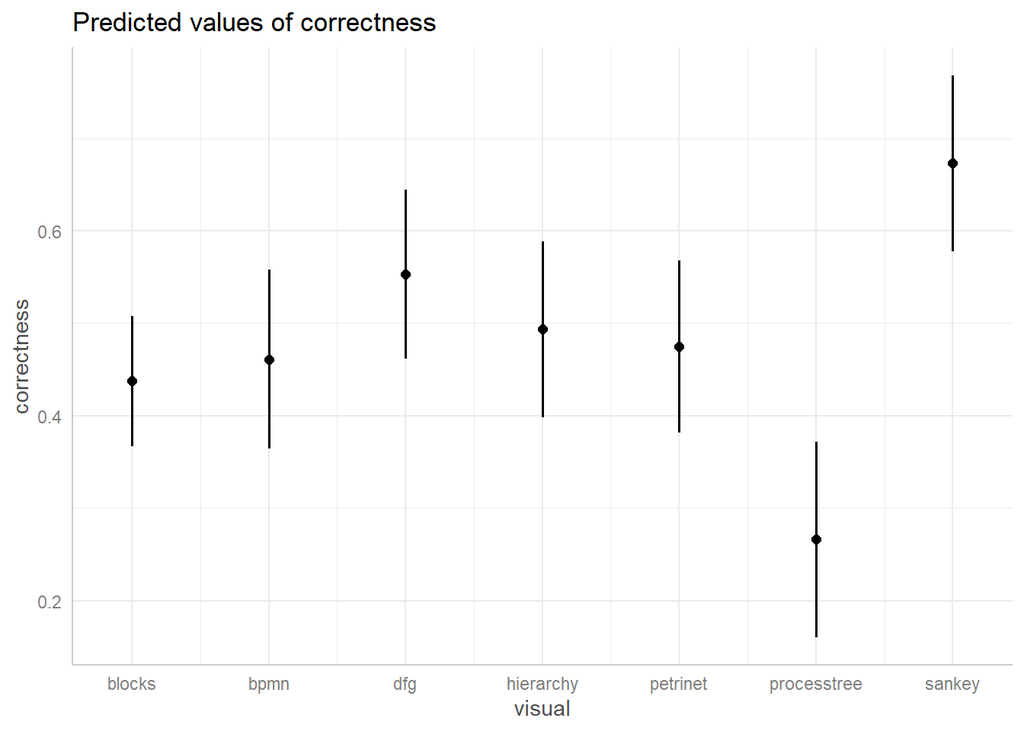

| term | levels | Estimate | Std. Error | df | t value | lower | upper | Pr(>\|t\|) |
| --- | --- | --- | --- | --- | --- | --- | --- | --- |
| visual | blocks - bpmn | -0.02 | 0.11 | 144.61 | -0.22 | -0.24 | 0.19 | 0.83 |
| visual | blocks - dfg | -0.12 | 0.10 | 143.13 | -1.11 | -0.32 | 0.09 | 0.27 |
| visual | blocks - hierarchy | -0.06 | 0.11 | 145.39 | -0.52 | -0.27 | 0.16 | 0.60 |
| visual | blocks - petrinet | -0.04 | 0.11 | 143.43 | -0.36 | -0.25 | 0.17 | 0.72 |
| visual | blocks - processtree | 0.17 | 0.12 | 146.88 | 1.46 | -0.06 | 0.40 | 0.15 |
| visual | blocks - sankey | -0.24 | 0.11 | 145.39 | -2.20 | -0.45 | -0.02 | 0.03 |
| visual | bpmn - dfg | -0.09 | 0.13 | 153.19 | -0.73 | -0.34 | 0.16 | 0.47 |
| visual | bpmn - hierarchy | -0.03 | 0.13 | 152.21 | -0.25 | -0.29 | 0.22 | 0.80 |
| visual | bpmn - petrinet | -0.01 | 0.13 | 149.73 | -0.11 | -0.26 | 0.24 | 0.91 |
| visual | bpmn - processtree | 0.19 | 0.14 | 154.91 | 1.42 | -0.08 | 0.47 | 0.16 |
| visual | bpmn - sankey | -0.21 | 0.13 | 147.13 | -1.68 | -0.46 | 0.04 | 0.09 |
| visual | dfg - hierarchy | 0.06 | 0.12 | 147.04 | 0.49 | -0.18 | 0.30 | 0.63 |
| visual | dfg - petrinet | 0.08 | 0.12 | 153.44 | 0.63 | -0.17 | 0.32 | 0.53 |
| visual | dfg - processtree | 0.29 | 0.13 | 153.41 | 2.15 | 0.02 | 0.55 | 0.03 |
| visual | dfg - sankey | -0.12 | 0.12 | 150.95 | -0.97 | -0.36 | 0.12 | 0.33 |
| visual | hierarchy - petrinet | 0.02 | 0.12 | 150.22 | 0.15 | -0.23 | 0.26 | 0.88 |
| visual | hierarchy - processtree | 0.23 | 0.13 | 151.90 | 1.69 | -0.04 | 0.49 | 0.09 |
| visual | hierarchy - sankey | -0.18 | 0.13 | 162.83 | -1.37 | -0.44 | 0.08 | 0.17 |
| visual | petrinet - processtree | 0.21 | 0.13 | 152.65 | 1.56 | -0.06 | 0.47 | 0.12 |
| visual | petrinet - sankey | -0.20 | 0.12 | 147.99 | -1.60 | -0.44 | 0.05 | 0.11 |
| visual | processtree - sankey | -0.41 | 0.13 | 149.85 | -3.04 | -0.67 | -0.14 | 2.79e-03 |

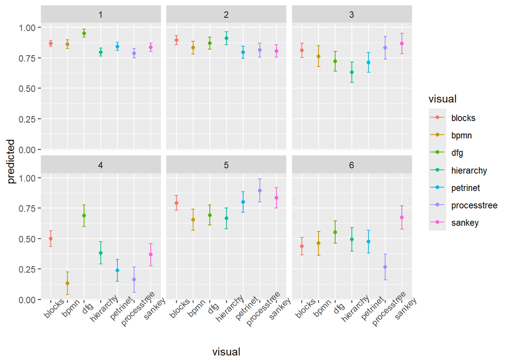

## Model 3T: Per task (logTime)

Multilevel linear regression models on logtime per task to test for effects of visualization per task, with pairwise differences

### Model 3at: task 1

|  | logtime |  |  |
| --- | --- | --- | --- |
| Predictors | Estimates | std. Error | p |
| (Intercept) | 10.44 | 0.09 | **<0.001** |
| visual [bpmn] | 0.60 | 0.14 | **<0.001** |
| visual [dfg] | -0.10 | 0.14 | 0.483 |
| visual [hierarchy] | -0.17 | 0.14 | 0.225 |
| visual [petrinet] | 0.59 | 0.14 | **<0.001** |
| visual [processtree] | 0.63 | 0.16 | **<0.001** |
| visual [sankey] | 0.36 | 0.14 | **0.013** |
| Random Effects |  |  |  |
| σ<sup>2</sup> | 0.31 |  |  |
| τ<sub>00</sub> <sub>p_id</sub> | 0.09 |  |  |
| ICC | 0.23 |  |  |
| N <sub>p_id</sub> | 48 |  |  |
| Observations | 189 |  |  |
| Marginal R<sup>2</sup> / Conditional R<sup>2</sup> | 0.200 / 0.385 |  |  |

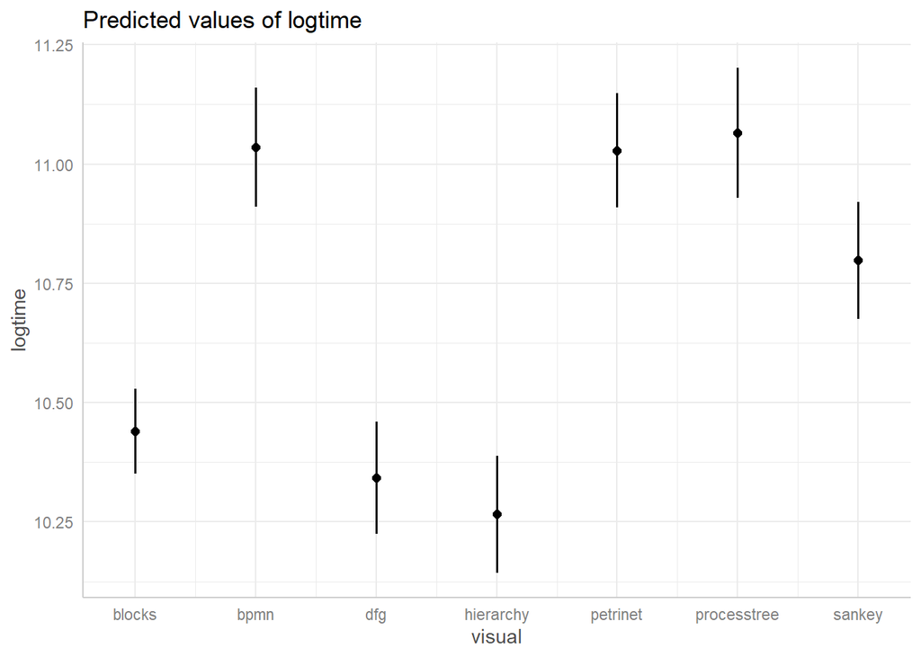

| term | levels | Estimate | Std. Error | df | t value | lower | upper | Pr(>\|t\|) |
| --- | --- | --- | --- | --- | --- | --- | --- | --- |
| visual | blocks - bpmn | -0.60 | 0.14 | 148.49 | -4.12 | -0.88 | -0.31 | 6.33e-05 |
| visual | blocks - dfg | 0.10 | 0.14 | 146.66 | 0.70 | -0.18 | 0.37 | 0.48 |
| visual | blocks - hierarchy | 0.17 | 0.14 | 149.13 | 1.22 | -0.11 | 0.46 | 0.23 |
| visual | blocks - petrinet | -0.59 | 0.14 | 147.08 | -4.20 | -0.87 | -0.31 | 4.67e-05 |
| visual | blocks - processtree | -0.63 | 0.16 | 151.25 | -4.02 | -0.93 | -0.32 | 9.08e-05 |
| visual | blocks - sankey | -0.36 | 0.14 | 149.13 | -2.51 | -0.64 | -0.08 | 0.01 |
| visual | bpmn - dfg | 0.69 | 0.17 | 158.81 | 4.15 | 0.36 | 1.02 | 5.47e-05 |
| visual | bpmn - hierarchy | 0.77 | 0.17 | 157.29 | 4.54 | 0.43 | 1.10 | 1.11e-05 |
| visual | bpmn - petrinet | 6.91e-03 | 0.17 | 154.96 | 0.04 | -0.32 | 0.34 | 0.97 |
| visual | bpmn - processtree | -0.03 | 0.18 | 160.98 | -0.16 | -0.39 | 0.33 | 0.87 |
| visual | bpmn - sankey | 0.24 | 0.17 | 151.58 | 1.42 | -0.09 | 0.57 | 0.16 |
| visual | dfg - hierarchy | 0.08 | 0.16 | 151.46 | 0.47 | -0.24 | 0.40 | 0.64 |
| visual | dfg - petrinet | -0.69 | 0.16 | 159.13 | -4.19 | -1.01 | -0.36 | 4.57e-05 |
| visual | dfg - processtree | -0.72 | 0.18 | 159.12 | -4.10 | -1.07 | -0.37 | 6.59e-05 |
| visual | dfg - sankey | -0.46 | 0.16 | 155.73 | -2.78 | -0.78 | -0.13 | 6.07e-03 |
| visual | hierarchy - petrinet | -0.76 | 0.17 | 154.98 | -4.62 | -1.09 | -0.44 | 8.09e-06 |
| visual | hierarchy - processtree | -0.80 | 0.18 | 157.05 | -4.48 | -1.15 | -0.45 | 1.41e-05 |
| visual | hierarchy - sankey | -0.53 | 0.17 | 169.39 | -3.08 | -0.87 | -0.19 | 2.43e-03 |
| visual | petrinet - processtree | -0.04 | 0.18 | 158.36 | -0.21 | -0.39 | 0.31 | 0.84 |
| visual | petrinet - sankey | 0.23 | 0.16 | 152.58 | 1.40 | -0.09 | 0.56 | 0.16 |
| visual | processtree - sankey | 0.27 | 0.18 | 154.79 | 1.51 | -0.08 | 0.62 | 0.13 |

### Model 3bt: task 2

|  | logtime |  |  |
| --- | --- | --- | --- |
| Predictors | Estimates | std. Error | p |
| (Intercept) | 10.87 | 0.11 | **<0.001** |
| visual [bpmn] | 0.23 | 0.17 | 0.179 |
| visual [dfg] | -0.18 | 0.16 | 0.284 |
| visual [hierarchy] | -0.07 | 0.17 | 0.684 |
| visual [petrinet] | 0.26 | 0.17 | 0.122 |
| visual [processtree] | 0.39 | 0.18 | **0.036** |
| visual [sankey] | 0.29 | 0.17 | 0.091 |
| Random Effects |  |  |  |
| σ<sup>2</sup> | 0.44 |  |  |
| τ<sub>00</sub> <sub>p_id</sub> | 0.10 |  |  |
| ICC | 0.19 |  |  |
| N <sub>p_id</sub> | 48 |  |  |
| Observations | 189 |  |  |
| Marginal R<sup>2</sup> / Conditional R<sup>2</sup> | 0.061 / 0.236 |  |  |

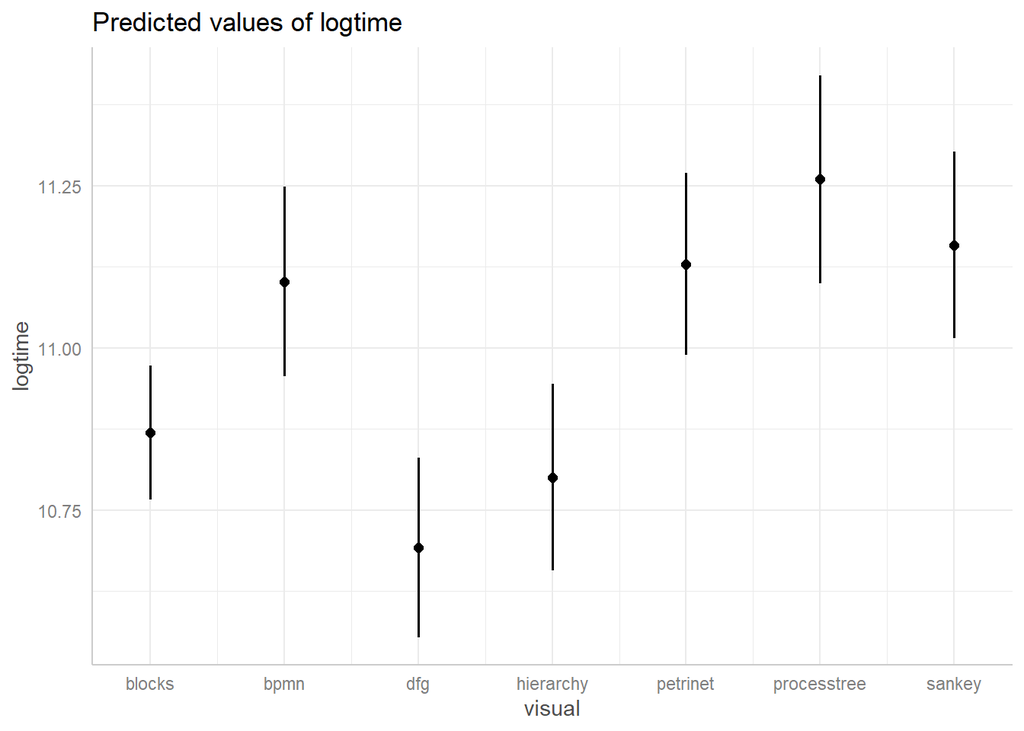

| term | levels | Estimate | Std. Error | df | t value | lower | upper | Pr(>\|t\|) |
| --- | --- | --- | --- | --- | --- | --- | --- | --- |
| visual | blocks - bpmn | -0.23 | 0.17 | 149.50 | -1.35 | -0.57 | 0.11 | 0.18 |
| visual | blocks - dfg | 0.18 | 0.16 | 147.40 | 1.08 | -0.15 | 0.50 | 0.28 |
| visual | blocks - hierarchy | 0.07 | 0.17 | 150.01 | 0.41 | -0.27 | 0.40 | 0.68 |
| visual | blocks - petrinet | -0.26 | 0.17 | 147.91 | -1.55 | -0.59 | 0.07 | 0.12 |
| visual | blocks - processtree | -0.39 | 0.18 | 152.64 | -2.11 | -0.76 | -0.02 | 0.04 |
| visual | blocks - sankey | -0.29 | 0.17 | 150.01 | -1.70 | -0.62 | 0.05 | 0.09 |
| visual | bpmn - dfg | 0.41 | 0.20 | 161.14 | 2.06 | 0.02 | 0.80 | 0.04 |
| visual | bpmn - hierarchy | 0.30 | 0.20 | 159.21 | 1.50 | -0.10 | 0.70 | 0.14 |
| visual | bpmn - petrinet | -0.03 | 0.20 | 157.01 | -0.14 | -0.42 | 0.37 | 0.89 |
| visual | bpmn - processtree | -0.16 | 0.22 | 163.64 | -0.73 | -0.58 | 0.27 | 0.47 |
| visual | bpmn - sankey | -0.06 | 0.20 | 153.03 | -0.28 | -0.45 | 0.34 | 0.78 |
| visual | dfg - hierarchy | -0.11 | 0.19 | 152.88 | -0.56 | -0.49 | 0.27 | 0.58 |
| visual | dfg - petrinet | -0.44 | 0.19 | 161.51 | -2.25 | -0.82 | -0.05 | 0.03 |
| visual | dfg - processtree | -0.57 | 0.21 | 161.52 | -2.71 | -0.98 | -0.15 | 7.46e-03 |
| visual | dfg - sankey | -0.47 | 0.19 | 157.41 | -2.40 | -0.85 | -0.08 | 0.02 |
| visual | hierarchy - petrinet | -0.33 | 0.20 | 156.64 | -1.68 | -0.72 | 0.06 | 0.10 |
| visual | hierarchy - processtree | -0.46 | 0.21 | 159.01 | -2.17 | -0.88 | -0.04 | 0.03 |
| visual | hierarchy - sankey | -0.36 | 0.20 | 172.34 | -1.75 | -0.76 | 0.05 | 0.08 |
| visual | petrinet - processtree | -0.13 | 0.21 | 160.77 | -0.62 | -0.55 | 0.29 | 0.54 |
| visual | petrinet - sankey | -0.03 | 0.20 | 154.12 | -0.15 | -0.42 | 0.36 | 0.88 |
| visual | processtree - sankey | 0.10 | 0.21 | 156.61 | 0.48 | -0.32 | 0.52 | 0.63 |

### Model 3ct: task 3

|  | logtime |  |  |
| --- | --- | --- | --- |
| Predictors | Estimates | std. Error | p |
| (Intercept) | 9.88 | 0.14 | **<0.001** |
| visual [bpmn] | -0.47 | 0.21 | **0.029** |
| visual [dfg] | 0.27 | 0.20 | 0.177 |
| visual [hierarchy] | 0.30 | 0.21 | 0.158 |
| visual [petrinet] | -0.33 | 0.20 | 0.110 |
| visual [processtree] | -0.30 | 0.23 | 0.188 |
| visual [sankey] | 0.05 | 0.21 | 0.816 |
| Random Effects |  |  |  |
| σ<sup>2</sup> | 0.65 |  |  |
| τ<sub>00</sub> <sub>p_id</sub> | 0.28 |  |  |
| ICC | 0.30 |  |  |
| N <sub>p_id</sub> | 48 |  |  |
| Observations | 189 |  |  |
| Marginal R<sup>2</sup> / Conditional R<sup>2</sup> | 0.069 / 0.347 |  |  |

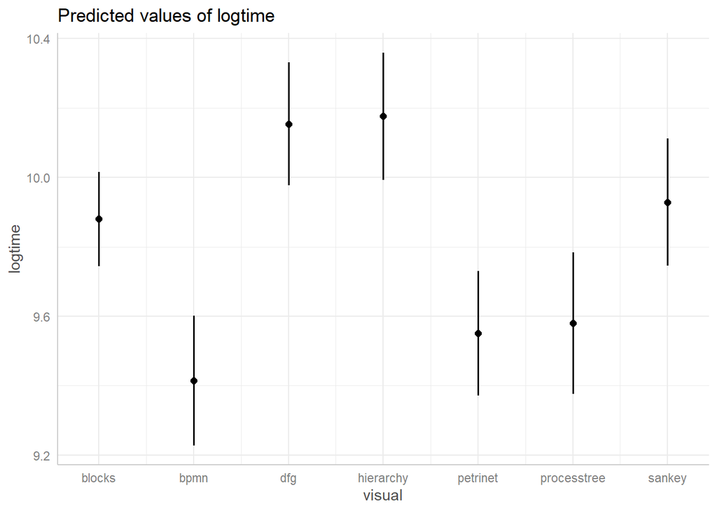

| term | levels | Estimate | Std. Error | df | t value | lower | upper | Pr(>\|t\|) |
| --- | --- | --- | --- | --- | --- | --- | --- | --- |
| visual | blocks - bpmn | 0.47 | 0.21 | 145.56 | 2.20 | 0.05 | 0.88 | 0.03 |
| visual | blocks - dfg | -0.27 | 0.20 | 144.01 | -1.36 | -0.67 | 0.13 | 0.18 |
| visual | blocks - hierarchy | -0.30 | 0.21 | 146.32 | -1.42 | -0.71 | 0.12 | 0.16 |
| visual | blocks - petrinet | 0.33 | 0.20 | 144.33 | 1.61 | -0.08 | 0.73 | 0.11 |
| visual | blocks - processtree | 0.30 | 0.23 | 147.92 | 1.32 | -0.15 | 0.75 | 0.19 |
| visual | blocks - sankey | -0.05 | 0.21 | 146.32 | -0.23 | -0.46 | 0.36 | 0.82 |
| visual | bpmn - dfg | -0.74 | 0.25 | 154.46 | -3.02 | -1.22 | -0.25 | 3.00e-03 |
| visual | bpmn - hierarchy | -0.76 | 0.25 | 153.39 | -3.06 | -1.25 | -0.27 | 2.58e-03 |
| visual | bpmn - petrinet | -0.14 | 0.25 | 150.93 | -0.56 | -0.62 | 0.35 | 0.58 |
| visual | bpmn - processtree | -0.16 | 0.27 | 156.27 | -0.62 | -0.69 | 0.36 | 0.54 |
| visual | bpmn - sankey | -0.51 | 0.25 | 148.18 | -2.10 | -1.00 | -0.03 | 0.04 |
| visual | dfg - hierarchy | -0.02 | 0.24 | 148.09 | -0.09 | -0.49 | 0.45 | 0.93 |
| visual | dfg - petrinet | 0.60 | 0.24 | 154.73 | 2.51 | 0.13 | 1.08 | 0.01 |
| visual | dfg - processtree | 0.57 | 0.26 | 154.70 | 2.22 | 0.06 | 1.09 | 0.03 |
| visual | dfg - sankey | 0.23 | 0.24 | 152.07 | 0.94 | -0.25 | 0.70 | 0.35 |
| visual | hierarchy - petrinet | 0.62 | 0.24 | 151.34 | 2.58 | 0.15 | 1.10 | 0.01 |
| visual | hierarchy - processtree | 0.60 | 0.26 | 153.09 | 2.28 | 0.08 | 1.11 | 0.02 |
| visual | hierarchy - sankey | 0.25 | 0.25 | 164.30 | 0.97 | -0.26 | 0.75 | 0.33 |
| visual | petrinet - processtree | -0.03 | 0.26 | 153.93 | -0.11 | -0.54 | 0.49 | 0.91 |
| visual | petrinet - sankey | -0.38 | 0.24 | 149.07 | -1.57 | -0.85 | 0.10 | 0.12 |
| visual | processtree - sankey | -0.35 | 0.26 | 150.99 | -1.34 | -0.86 | 0.16 | 0.18 |

### Model 3dt: task 4

|  | logtime |  |  |
| --- | --- | --- | --- |
| Predictors | Estimates | std. Error | p |
| (Intercept) | 10.20 | 0.15 | **<0.001** |
| visual [bpmn] | 0.26 | 0.21 | 0.224 |
| visual [dfg] | -0.29 | 0.20 | 0.162 |
| visual [hierarchy] | -0.09 | 0.21 | 0.684 |
| visual [petrinet] | 0.30 | 0.21 | 0.157 |
| visual [processtree] | 0.00 | 0.23 | 0.988 |
| visual [sankey] | -0.41 | 0.21 | 0.057 |
| Random Effects |  |  |  |
| σ<sup>2</sup> | 0.67 |  |  |
| τ<sub>00</sub> <sub>p_id</sub> | 0.36 |  |  |
| ICC | 0.35 |  |  |
| N <sub>p_id</sub> | 48 |  |  |
| Observations | 189 |  |  |
| Marginal R<sup>2</sup> / Conditional R<sup>2</sup> | 0.049 / 0.379 |  |  |

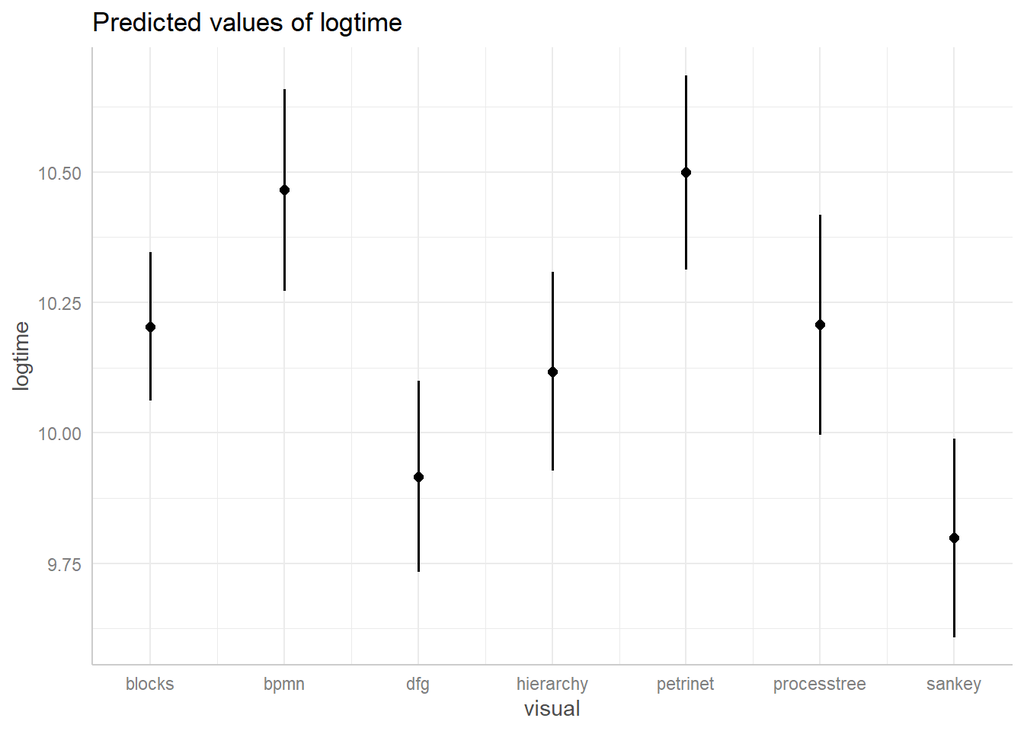

| term | levels | Estimate | Std. Error | df | t value | lower | upper | Pr(>\|t\|) |
| --- | --- | --- | --- | --- | --- | --- | --- | --- |
| visual | blocks - bpmn | -0.26 | 0.21 | 144.11 | -1.22 | -0.69 | 0.16 | 0.22 |
| visual | blocks - dfg | 0.29 | 0.20 | 142.76 | 1.41 | -0.12 | 0.69 | 0.16 |
| visual | blocks - hierarchy | 0.09 | 0.21 | 144.90 | 0.41 | -0.33 | 0.50 | 0.68 |
| visual | blocks - petrinet | -0.30 | 0.21 | 143.02 | -1.42 | -0.71 | 0.12 | 0.16 |
| visual | blocks - processtree | -3.37e-03 | 0.23 | 146.19 | -0.01 | -0.46 | 0.45 | 0.99 |
| visual | blocks - sankey | 0.41 | 0.21 | 144.90 | 1.92 | -0.01 | 0.82 | 0.06 |
| visual | bpmn - dfg | 0.55 | 0.25 | 152.00 | 2.21 | 0.06 | 1.04 | 0.03 |
| visual | bpmn - hierarchy | 0.35 | 0.25 | 151.18 | 1.38 | -0.15 | 0.85 | 0.17 |
| visual | bpmn - petrinet | -0.03 | 0.25 | 148.76 | -0.14 | -0.53 | 0.46 | 0.89 |
| visual | bpmn - processtree | 0.26 | 0.27 | 153.56 | 0.95 | -0.28 | 0.80 | 0.34 |
| visual | bpmn - sankey | 0.67 | 0.25 | 146.41 | 2.68 | 0.18 | 1.16 | 8.21e-03 |
| visual | dfg - hierarchy | -0.20 | 0.24 | 146.34 | -0.84 | -0.68 | 0.28 | 0.40 |
| visual | dfg - petrinet | -0.58 | 0.24 | 152.23 | -2.39 | -1.07 | -0.10 | 0.02 |
| visual | dfg - processtree | -0.29 | 0.26 | 152.19 | -1.11 | -0.81 | 0.23 | 0.27 |
| visual | dfg - sankey | 0.12 | 0.24 | 150.04 | 0.48 | -0.36 | 0.60 | 0.63 |
| visual | hierarchy - petrinet | -0.38 | 0.25 | 149.34 | -1.55 | -0.87 | 0.10 | 0.12 |
| visual | hierarchy - processtree | -0.09 | 0.27 | 150.87 | -0.34 | -0.61 | 0.44 | 0.74 |
| visual | hierarchy - sankey | 0.32 | 0.26 | 161.05 | 1.23 | -0.19 | 0.83 | 0.22 |
| visual | petrinet - processtree | 0.29 | 0.26 | 151.45 | 1.10 | -0.23 | 0.82 | 0.27 |
| visual | petrinet - sankey | 0.70 | 0.24 | 147.22 | 2.87 | 0.22 | 1.18 | 4.75e-03 |
| visual | processtree - sankey | 0.41 | 0.26 | 148.93 | 1.55 | -0.11 | 0.93 | 0.12 |

### Model 3et: task 5

|  | logtime |  |  |
| --- | --- | --- | --- |
| Predictors | Estimates | std. Error | p |
| (Intercept) | 10.04 | 0.09 | **<0.001** |
| visual [bpmn] | 0.24 | 0.15 | 0.124 |
| visual [dfg] | -0.01 | 0.15 | 0.962 |
| visual [hierarchy] | -0.14 | 0.15 | 0.366 |
| visual [petrinet] | 0.02 | 0.15 | 0.902 |
| visual [processtree] | 0.23 | 0.17 | 0.163 |
| visual [sankey] | 0.16 | 0.15 | 0.300 |
| Random Effects |  |  |  |
| σ<sup>2</sup> | 0.35 |  |  |
| τ<sub>00</sub> <sub>p_id</sub> | 0.07 |  |  |
| ICC | 0.17 |  |  |
| N <sub>p_id</sub> | 48 |  |  |
| Observations | 189 |  |  |
| Marginal R<sup>2</sup> / Conditional R<sup>2</sup> | 0.034 / 0.200 |  |  |

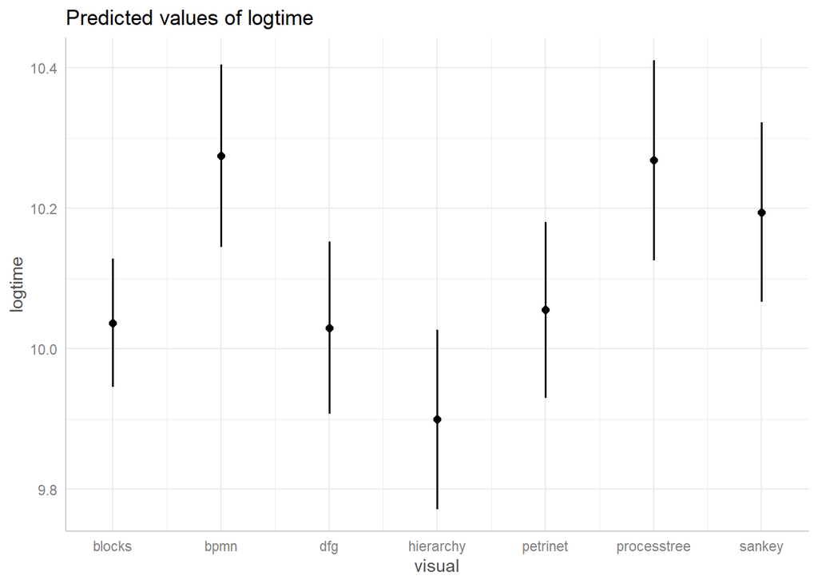

| term | levels | Estimate | Std. Error | df | t value | lower | upper | Pr(>\|t\|) |
| --- | --- | --- | --- | --- | --- | --- | --- | --- |
| visual | blocks - bpmn | -0.24 | 0.15 | 150.08 | -1.55 | -0.54 | 0.07 | 0.12 |
| visual | blocks - dfg | 7.02e-03 | 0.15 | 147.89 | 0.05 | -0.28 | 0.30 | 0.96 |
| visual | blocks - hierarchy | 0.14 | 0.15 | 150.53 | 0.91 | -0.16 | 0.44 | 0.37 |
| visual | blocks - petrinet | -0.02 | 0.15 | 148.44 | -0.12 | -0.31 | 0.28 | 0.90 |
| visual | blocks - processtree | -0.23 | 0.17 | 153.33 | -1.40 | -0.56 | 0.09 | 0.16 |
| visual | blocks - sankey | -0.16 | 0.15 | 150.53 | -1.04 | -0.46 | 0.14 | 0.30 |
| visual | bpmn - dfg | 0.24 | 0.18 | 162.10 | 1.38 | -0.10 | 0.59 | 0.17 |
| visual | bpmn - hierarchy | 0.37 | 0.18 | 160.02 | 2.09 | 0.02 | 0.73 | 0.04 |
| visual | bpmn - petrinet | 0.22 | 0.18 | 157.91 | 1.24 | -0.13 | 0.57 | 0.22 |
| visual | bpmn - processtree | 6.33e-03 | 0.19 | 164.69 | 0.03 | -0.37 | 0.39 | 0.97 |
| visual | bpmn - sankey | 0.08 | 0.18 | 153.74 | 0.45 | -0.27 | 0.43 | 0.65 |
| visual | dfg - hierarchy | 0.13 | 0.17 | 153.57 | 0.76 | -0.21 | 0.47 | 0.45 |
| visual | dfg - petrinet | -0.03 | 0.17 | 162.49 | -0.15 | -0.37 | 0.32 | 0.88 |
| visual | dfg - processtree | -0.24 | 0.19 | 162.50 | -1.28 | -0.61 | 0.13 | 0.20 |
| visual | dfg - sankey | -0.16 | 0.17 | 158.16 | -0.95 | -0.51 | 0.18 | 0.34 |
| visual | hierarchy - petrinet | -0.16 | 0.17 | 157.39 | -0.89 | -0.50 | 0.19 | 0.37 |
| visual | hierarchy - processtree | -0.37 | 0.19 | 159.85 | -1.95 | -0.74 | 4.23e-03 | 0.05 |
| visual | hierarchy - sankey | -0.29 | 0.18 | 173.37 | -1.62 | -0.65 | 0.06 | 0.11 |
| visual | petrinet - processtree | -0.21 | 0.19 | 161.77 | -1.13 | -0.58 | 0.16 | 0.26 |
| visual | petrinet - sankey | -0.14 | 0.17 | 154.85 | -0.80 | -0.48 | 0.21 | 0.43 |
| visual | processtree - sankey | 0.07 | 0.19 | 157.42 | 0.39 | -0.30 | 0.45 | 0.70 |

### Model 3ft: task 6

and overall plot for all 6 tasks

|  | logtime |  |  |
| --- | --- | --- | --- |
| Predictors | Estimates | std. Error | p |
| (Intercept) | 10.98 | 0.13 | **<0.001** |
| visual [bpmn] | -0.13 | 0.21 | 0.538 |
| visual [dfg] | 0.40 | 0.20 | **0.045** |
| visual [hierarchy] | -0.16 | 0.20 | 0.421 |
| visual [petrinet] | -0.18 | 0.20 | 0.364 |
| visual [processtree] | 0.45 | 0.22 | **0.044** |
| visual [sankey] | -0.44 | 0.20 | **0.030** |
| Random Effects |  |  |  |
| σ<sup>2</sup> | 0.62 |  |  |
| τ<sub>00</sub> <sub>p_id</sub> | 0.15 |  |  |
| ICC | 0.20 |  |  |
| N <sub>p_id</sub> | 48 |  |  |
| Observations | 189 |  |  |
| Marginal R<sup>2</sup> / Conditional R<sup>2</sup> | 0.089 / 0.269 |  |  |

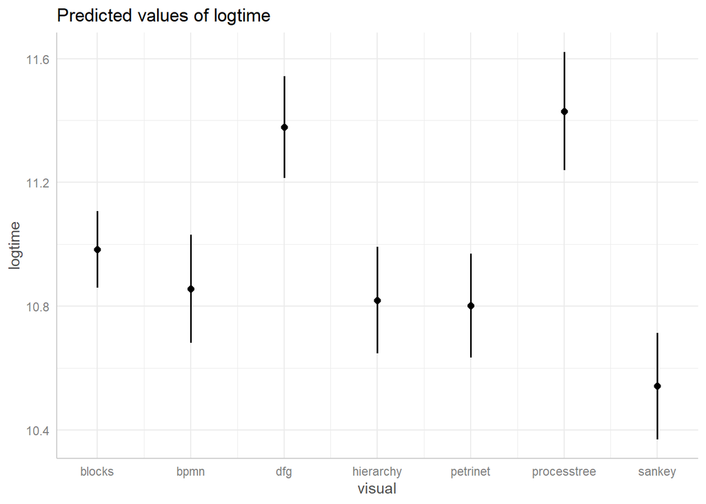

| term | levels | Estimate | Std. Error | df | t value | lower | upper | Pr(>\|t\|) |
| --- | --- | --- | --- | --- | --- | --- | --- | --- |
| visual | blocks - bpmn | 0.13 | 0.21 | 147.93 | 0.62 | -0.28 | 0.53 | 0.54 |
| visual | blocks - dfg | -0.40 | 0.20 | 145.83 | -2.02 | -0.78 | -8.50e-03 | 0.05 |
| visual | blocks - hierarchy | 0.16 | 0.20 | 148.49 | 0.81 | -0.24 | 0.56 | 0.42 |
| visual | blocks - petrinet | 0.18 | 0.20 | 146.34 | 0.91 | -0.21 | 0.57 | 0.36 |
| visual | blocks - processtree | -0.45 | 0.22 | 151.07 | -2.03 | -0.88 | -0.01 | 0.04 |
| visual | blocks - sankey | 0.44 | 0.20 | 148.49 | 2.18 | 0.04 | 0.84 | 0.03 |
| visual | bpmn - dfg | -0.52 | 0.24 | 159.63 | -2.21 | -0.99 | -0.06 | 0.03 |
| visual | bpmn - hierarchy | 0.04 | 0.24 | 157.73 | 0.15 | -0.44 | 0.51 | 0.88 |
| visual | bpmn - petrinet | 0.05 | 0.24 | 155.41 | 0.23 | -0.41 | 0.52 | 0.82 |
| visual | bpmn - processtree | -0.57 | 0.26 | 162.13 | -2.23 | -1.08 | -0.07 | 0.03 |
| visual | bpmn - sankey | 0.31 | 0.24 | 151.46 | 1.33 | -0.15 | 0.78 | 0.19 |
| visual | dfg - hierarchy | 0.56 | 0.23 | 151.31 | 2.43 | 0.10 | 1.01 | 0.02 |
| visual | dfg - petrinet | 0.58 | 0.23 | 160.00 | 2.49 | 0.12 | 1.03 | 0.01 |
| visual | dfg - processtree | -0.05 | 0.25 | 160.00 | -0.21 | -0.54 | 0.44 | 0.84 |
| visual | dfg - sankey | 0.84 | 0.23 | 155.94 | 3.61 | 0.38 | 1.30 | 4.07e-04 |
| visual | hierarchy - petrinet | 0.02 | 0.23 | 155.14 | 0.08 | -0.44 | 0.48 | 0.94 |
| visual | hierarchy - processtree | -0.61 | 0.25 | 157.51 | -2.42 | -1.11 | -0.11 | 0.02 |
| visual | hierarchy - sankey | 0.28 | 0.24 | 171.14 | 1.14 | -0.20 | 0.76 | 0.26 |
| visual | petrinet - processtree | -0.63 | 0.25 | 159.22 | -2.50 | -1.13 | -0.13 | 0.01 |
| visual | petrinet - sankey | 0.26 | 0.23 | 152.56 | 1.12 | -0.20 | 0.72 | 0.27 |
| visual | processtree - sankey | 0.89 | 0.25 | 155.06 | 3.54 | 0.39 | 1.39 | 5.35e-04 |

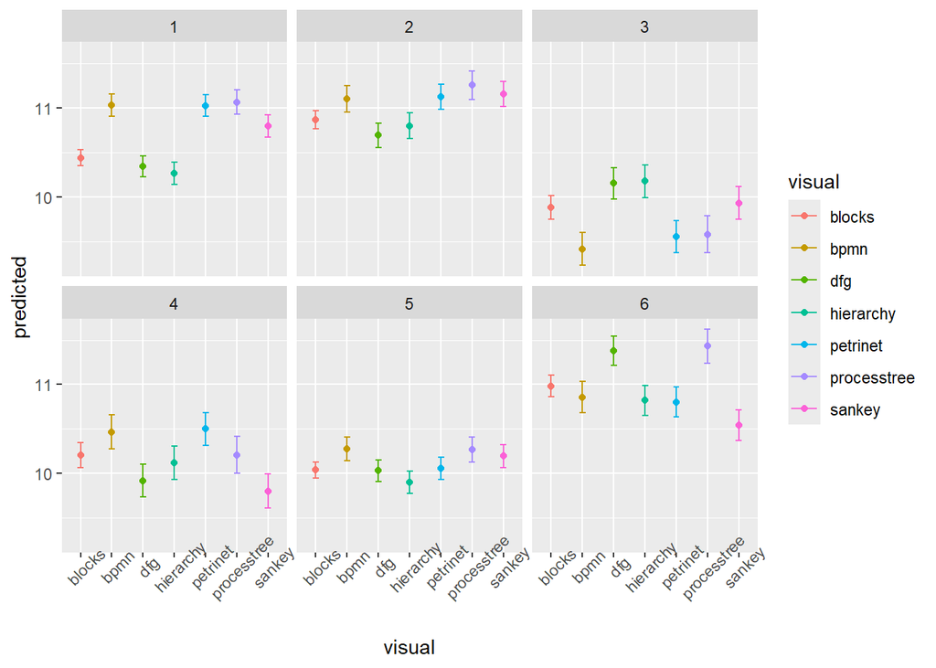

## Model 4: analysing the ranking of the visualizations

### model 4a: ranking by visualization

```
##            variable   coef scaled.coef exp(coef) se(coef) se(scaled.coef)
## 1        visualbpmn  0.075       0.069     1.077    0.345           0.321
## 2         visualdfg  1.360       1.267     3.897    0.352           0.328
## 3   visualhierarchy -0.114      -0.107     0.892    0.342           0.318
## 4    visualpetrinet  0.234       0.218     1.264    0.324           0.302
## 5 visualprocesstree  0.826       0.770     2.284    0.388           0.362
## 6      visualsankey  0.095       0.089     1.100    0.337           0.314
##        z Pr(>|z|)
## 1  0.216    0.829
## 2  3.860    0.000
## 3 -0.335    0.738
## 4  0.724    0.469
## 5  2.128    0.033
## 6  0.283    0.777
```

### Model 4b: ranking by visualization and correctness:

interaction terms show to what extent the ranking depends on whether the participant correctly answered the questions

```
##                     variable   coef scaled.coef exp(coef) se(coef)
## 1                 visualbpmn  3.843       3.403    46.649    1.501
## 2                  visualdfg  1.491       1.321     4.444    2.042
## 3            visualhierarchy  0.495       0.438     1.640    1.524
## 4             visualpetrinet  0.960       0.850     2.613    1.411
## 5          visualprocesstree -0.109      -0.097     0.896    2.290
## 6               visualsankey  1.656       1.467     5.239    1.889
## 7       visualblocks.avg_cor -0.562      -0.497     0.570    1.294
## 8         visualbpmn.avg_cor -6.758      -5.985     0.001    2.172
## 9          visualdfg.avg_cor -0.590      -0.522     0.555    2.371
## 10   visualhierarchy.avg_cor -1.589      -1.407     0.204    1.961
## 11    visualpetrinet.avg_cor -1.804      -1.597     0.165    1.775
## 12 visualprocesstree.avg_cor  0.768       0.681     2.157    3.262
## 13      visualsankey.avg_cor -2.647      -2.344     0.071    2.282
##    se(scaled.coef)      z Pr(>|z|)
## 1            1.330  2.559    0.010
## 2            1.808  0.730    0.465
## 3            1.350  0.324    0.746
## 4            1.249  0.681    0.496
## 5            2.028 -0.048    0.962
## 6            1.673  0.877    0.381
## 7            1.146 -0.434    0.664
## 8            1.924 -3.111    0.002
## 9            2.100 -0.249    0.804
## 10           1.736 -0.810    0.418
## 11           1.572 -1.016    0.310
## 12           2.889  0.236    0.814
## 13           2.021 -1.160    0.246
```

### Model 4c: ranking by visualization and understandability

interaction terms show to what extent the ranking depends on whether the participant reported understanding the visualization

```
##                 variable   coef scaled.coef exp(coef) se(coef) se(scaled.coef)
## 1             visualbpmn  1.830       1.399     6.232    0.934           0.714
## 2              visualdfg  0.964       0.737     2.622    0.850           0.650
## 3        visualhierarchy  1.497       1.144     4.467    1.056           0.807
## 4         visualpetrinet  1.843       1.409     6.312    0.971           0.742
## 5      visualprocesstree  0.800       0.611     2.225    0.866           0.662
## 6           visualsankey -0.518      -0.396     0.596    0.999           0.764
## 7       visualblocks.und -0.207      -0.159     0.813    0.069           0.053
## 8         visualbpmn.und -0.510      -0.390     0.600    0.121           0.093
## 9          visualdfg.und -0.228      -0.174     0.796    0.106           0.081
## 10   visualhierarchy.und -0.412      -0.315     0.662    0.127           0.097
## 11    visualpetrinet.und -0.434      -0.332     0.648    0.108           0.082
## 12 visualprocesstree.und -0.412      -0.315     0.662    0.135           0.103
## 13      visualsankey.und -0.147      -0.112     0.864    0.106           0.081
##         z Pr(>|z|)
## 1   1.958    0.050
## 2   1.134    0.257
## 3   1.418    0.156
## 4   1.898    0.058
## 5   0.923    0.356
## 6  -0.518    0.604
## 7  -3.000    0.003
## 8  -4.208    0.000
## 9  -2.160    0.031
## 10 -3.236    0.001
## 11 -4.036    0.000
## 12 -3.057    0.002
## 13 -1.379    0.168
```